# Projet Analyse de données

Rudio et Léo-Paul

2023-05-09

# Présentation du projet et du jeu de données

Le jeu de données est constitués d’informations sur la vie d’étudiants dans une université du Portugal. Ces informations vont de leur résultats universitaires, leur vie familiale à leur consommation d’alcool. Le jeu a été construit à partir d’une enquête menée auprès d’étudiant en mathématiques et en portugais.

L’objectif serait alors d’analyser le jeu de données afin de comprendre les facteurs qui impactent la réussite scolaire de ces étudiants. L’intérêt du jeu est la grande variété de facteurs proposée qui permet de courvrir un maximum d’hypothèsesn, notamment celle sur la consommation d’alcool proposée directement par le nom du jeu de données.

Voici les variabales présentent dans ce jeu de données ;

- **school** - student’s school (binary: ‘GP’ - Gabriel Pereira or ‘MS’ - Mousinho da Silveira)
- **sex** - student’s sex (binary: ‘F’ - female or ‘M’ - male)
- **age** - student’s age (numeric: from 15 to 22)
- **address** - student’s home address type (binary: ‘U’ - urban or ‘R’ - rural)
- **famsize** - family size (binary: ‘LE3’ - less or equal to 3 or ‘GT3’ - greater than 3)
- **Pstatus** - parent’s cohabitation status (binary: ‘T’ - living together or ‘A’ - apart)
- **Medu** - mother’s education (numeric: 0 - none, 1 - primary education (4th grade), 2 – 5th to 9th grade, 3 – secondary education or 4 – higher education)
- **Fedu** - father’s education (numeric: 0 - none, 1 - primary education (4th grade), 2 – 5th to 9th grade, 3 – secondary education or 4 – higher education)
- **Mjob** - mother’s job (nominal: ‘teacher’, ‘health’ care related, civil ‘services’ (e.g. administrative or police), ‘at_home’ or ‘other’)
- **Fjob** - father’s job (nominal: ‘teacher’, ‘health’ care related, civil ‘services’ (e.g. administrative or police), ‘at_home’ or ‘other’)
- **reason** - reason to choose this school (nominal: close to ‘home’, school ‘reputation’, ‘course’ preference or ‘other’)
- **guardian** - student’s guardian (nominal: ‘mother’, ‘father’ or ‘other’)
- **traveltime** - home to school travel time (numeric: 1 - <15 min., 2 - 15 to 30 min., 3 - 30 min. to 1 hour, or 4 - >1 hour)
- **studytime** - weekly study time (numeric: 1 - <2 hours, 2 - 2 to 5 hours, 3 - 5 to 10 hours, or 4 - >10 hours)
- **failures** - number of past class failures (numeric: n if 1<=n<3, else 4)
- **schoolsup** - extra educational support (binary: yes or no)
- **famsup** - family educational support (binary: yes or no)
- **paid** - extra paid classes within the course subject (Math or Portuguese) (binary: yes or no)
- **activities** - extra-curricular activities (binary: yes or no)
- **nursery** - attended nursery school (binary: yes or no)
- **higher** - wants to take higher education (binary: yes or no)
- **internet** - Internet access at home (binary: yes or no)
- **romantic** - with a romantic relationship (binary: yes or no)
- **famrel** - quality of family relationships (numeric: from 1 - very bad to 5 - excellent)
- **freetime** - free time after school (numeric: from 1 - very low to 5 - very high)
- **goout** - going out with friends (numeric: from 1 - very low to 5 - very high)
- **Dalc** - workday alcohol consumption (numeric: from 1 - very low to 5 - very high)
- **Walc** - weekend alcohol consumption (numeric: from 1 - very low to 5 - very high)
- **health** - current health status (numeric: from 1 - very bad to 5 - very good)
- **absences** - number of school absences (numeric: from 0 to 93)

These grades are related with the course subject, Math or Portuguese: - **G1** - first period grade (numeric: from 0 to 20) - **G2** - second period grade (numeric: from 0 to 20) - **G3** - final grade (numeric: from 0 to 20, output target)

Au cours de ce projet, nous nous concentrons sur la variable G3 qui est la variable de sortie représentant la note finale des élèves. Il s’agirait donc d’un problème de régression sur la variables G3 ou même plus généralement un problème de classification.

Voici les étapes que nous allons suivre :

1. Identifier les variables significatives
2. Appliquer des méthodes de classification sur la réussite scolaire
3. Effectuer une regression linéaires pour prédire G3
4. Comparer des méthodes de machine learning pour prédire G3

## 1.Chargement des données

```r
# Chargement de la base de données
df.mat=read.table("student-mat.csv",sep=",",header=TRUE,as.is = FALSE)
df.por=read.table("student-por.csv",sep=",",header=TRUE,as.is = FALSE)

# Etudiants qui appartiennent aux deux cours
both= merge(df.mat,df.por,by=c("school","sex","age","address","famsize","Pstatus","Medu","Fedu","Mjob","Fjob","reason","nursery","internet"))

# Concaténation des deux dataframes
df = rbind(df.mat,df.por)
head(df)
```

```
##   school sex age address famsize Pstatus Medu Fedu     Mjob     Fjob     reason
## 1     GP   F  18       U     GT3       A    4    4  at_home  teacher     course
## 2     GP   F  17       U     GT3       T    1    1  at_home    other     course
## 3     GP   F  15       U     LE3       T    1    1  at_home    other      other
## 4     GP   F  15       U     GT3       T    4    2   health services       home
## 5     GP   F  16       U     GT3       T    3    3    other    other       home
## 6     GP   M  16       U     LE3       T    4    3 services    other reputation
##   guardian traveltime studytime failures schoolsup famsup paid activities
## 1   mother          2         2        0       yes     no   no         no
## 2   father          1         2        0        no    yes   no         no
## 3   mother          1         2        3       yes     no  yes         no
## 4   mother          1         3        0        no    yes  yes        yes
## 5   father          1         2        0        no    yes  yes         no
## 6   mother          1         2        0        no    yes  yes        yes
##   nursery higher internet romantic famrel freetime goout Dalc Walc health
## 1     yes    yes       no       no      4        3     4    1    1      3
## 2      no    yes      yes       no      5        3     3    1    1      3
## 3     yes    yes      yes       no      4        3     2    2    3      3
## 4     yes    yes      yes      yes      3        2     2    1    1      5
## 5     yes    yes       no       no      4        3     2    1    2      5
## 6     yes    yes      yes       no      5        4     2    1    2      5
##   absences G1 G2 G3
## 1        6  5  6  6
## 2        4  5  5  6
## 3       10  7  8 10
## 4        2 15 14 15
## 5        4  6 10 10
## 6       10 15 15 15
```

## 2. Nettoyage et vérification des données

Le jeu est composé de 33 variables dont 17 qualitatives et 16 quantitatives. On calcule la moyenne pour chaque élève, et on rajoute une variable pour la réussite scolaire.

```r
print(str(df))
```

```
## 'data.frame':    1044 obs. of  33 variables:
##  $ school    : Factor w/ 2 levels "GP","MS": 1 1 1 1 1 1 1 1 1 1 ...
##  $ sex       : Factor w/ 2 levels "F","M": 1 1 1 1 1 2 2 1 2 2 ...
##  $ age       : int  18 17 15 15 16 16 16 17 15 15 ...
##  $ address   : Factor w/ 2 levels "R","U": 2 2 2 2 2 2 2 2 2 2 ...
##  $ famsize   : Factor w/ 2 levels "GT3","LE3": 1 1 2 1 1 2 2 1 2 1 ...
##  $ Pstatus   : Factor w/ 2 levels "A","T": 1 2 2 2 2 2 2 1 1 2 ...
##  $ Medu      : int  4 1 1 4 3 4 2 4 3 3 ...
##  $ Fedu      : int  4 1 1 2 3 3 2 4 2 4 ...
##  $ Mjob      : Factor w/ 5 levels "at_home","health",..: 1 1 1 2 3 4 3 3 4 3 ...
##  $ Fjob      : Factor w/ 5 levels "at_home","health",..: 5 3 3 4 3 3 3 5 3 3 ...
##  $ reason    : Factor w/ 4 levels "course","home",..: 1 1 3 2 2 4 2 2 2 2 ...
##  $ guardian  : Factor w/ 3 levels "father","mother",..: 2 1 2 2 1 2 2 2 2 2 ...
##  $ traveltime: int  2 1 1 1 1 1 1 2 1 1 ...
##  $ studytime : int  2 2 2 3 2 2 2 2 2 2 ...
```

[output cut: 20 more lines]

```r
print(nrow(df))
```

```
## [1] 1044
```

```r
## On calcule la moyenne des étudiants
df$Moy = (df$G1+df$G2+df$G3)/3

## On rajoute la réussite scolaire comme variable qualitative que nous devrons prédire.
df$RS = factor(df$Moy>=10)
head(df)
```

```
##   school sex age address famsize Pstatus Medu Fedu     Mjob     Fjob     reason
## 1     GP   F  18       U     GT3       A    4    4  at_home  teacher     course
## 2     GP   F  17       U     GT3       T    1    1  at_home    other     course
## 3     GP   F  15       U     LE3       T    1    1  at_home    other      other
## 4     GP   F  15       U     GT3       T    4    2   health services       home
## 5     GP   F  16       U     GT3       T    3    3    other    other       home
## 6     GP   M  16       U     LE3       T    4    3 services    other reputation
##   guardian traveltime studytime failures schoolsup famsup paid activities
## 1   mother          2         2        0       yes     no   no         no
## 2   father          1         2        0        no    yes   no         no
## 3   mother          1         2        3       yes     no  yes         no
## 4   mother          1         3        0        no    yes  yes        yes
## 5   father          1         2        0        no    yes  yes         no
## 6   mother          1         2        0        no    yes  yes        yes
##   nursery higher internet romantic famrel freetime goout Dalc Walc health
## 1     yes    yes       no       no      4        3     4    1    1      3
## 2      no    yes      yes       no      5        3     3    1    1      3
## 3     yes    yes      yes       no      4        3     2    2    3      3
## 4     yes    yes      yes      yes      3        2     2    1    1      5
## 5     yes    yes       no       no      4        3     2    1    2      5
## 6     yes    yes      yes       no      5        4     2    1    2      5
##   absences G1 G2 G3       Moy    RS
## 1        6  5  6  6  5.666667 FALSE
## 2        4  5  5  6  5.333333 FALSE
## 3       10  7  8 10  8.333333 FALSE
## 4        2 15 14 15 14.666667  TRUE
## 5        4  6 10 10  8.666667 FALSE
## 6       10 15 15 15 15.000000  TRUE
```

# 3. Exploration des données : études des variables

Cette partie consiste à appliquer des méthodes de statistiques descriptives afin de mieux comprendre le jeu de données. On se concentre sur l’analyse de la distribution des variables et leur corrélation avec les résultats scolaires.

## Les variables qualitatives

### Le sexe des étudiants

D’après le diagramme, le dataset est plutôt équilibré en terme d’hommes et de femmes,il y même plus de femmes que d’hommes dans ce lycées. On étudie ensuite le lien entre le sexe et les notes en effectant une ANOVA1. D’après le test de Fisher, p-value > 5% donc il n’y a pas d’effet du sexe sur les notes. D’après le test d’indépendances de Chi2 avec l’admission, le sexe des élèves n’a pas de lien avec leur réussite scolaire.

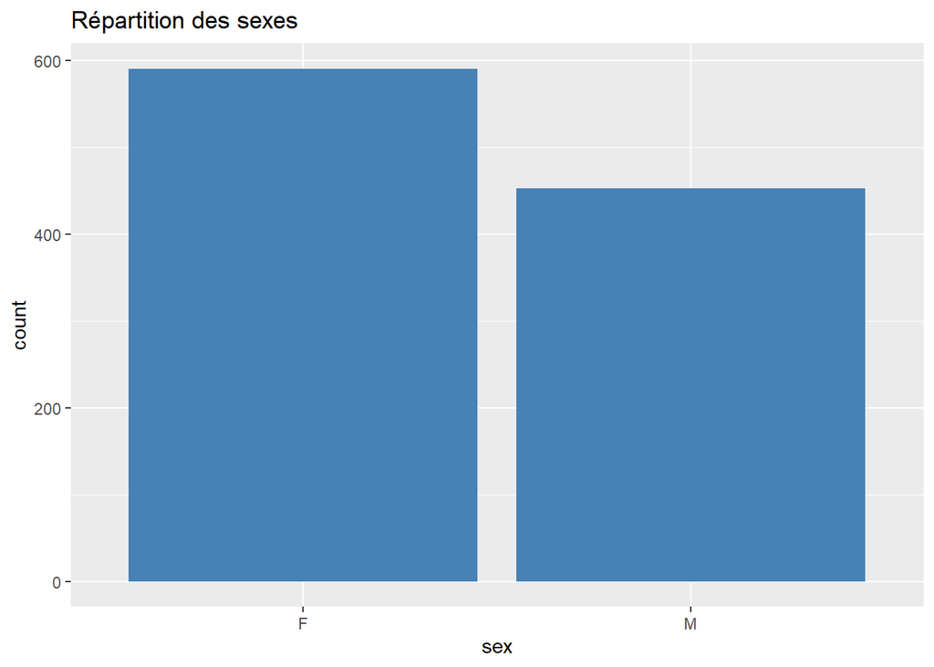

```r
# Distribution
library(ggplot2)
ggplot(df, aes(x = sex)) +
  geom_bar(fill = "steelblue") +
  labs(title = "Répartition des sexes")
```

```r
# Lien avec la moyenne
summary(lm(Moy ~ sex,data=df))
```

```
##
## Call:
## lm(formula = Moy ~ sex, data = df)
##
## Residuals:
##      Min       1Q   Median       3Q      Max
## -10.0152  -2.0152  -0.0152   2.1722   8.1722
##
## Coefficients:
##             Estimate Std. Error t value Pr(>|t|)
## (Intercept)  11.3486     0.1324  85.706   <2e-16 ***
## sexM         -0.1874     0.2010  -0.932    0.351
## ---
## Signif. codes:  0 '***' 0.001 '**' 0.01 '*' 0.05 '.' 0.1 ' ' 1
##
## Residual standard error: 3.219 on 1042 degrees of freedom
## Multiple R-squared:  0.0008335,  Adjusted R-squared:  -0.0001254
## F-statistic: 0.8693 on 1 and 1042 DF,  p-value: 0.3514
```

```r
# Lien avec la réussite
chisq.test(df$sex,df$RS)
```

```
##
##  Pearson's Chi-squared test with Yates' continuity correction
##
## data:  df$sex and df$RS
## X-squared = 0.49816, df = 1, p-value = 0.4803
```

### La taille de la famille

On a deux fois plus de grandes familles que de petites familles. D’après le test de Fisher, il y a bien un impactde taille de la famille sur les notes. Le test d’indépendance avec la réussite indique cependant que la taille de la famille n’est pas liée à la réussite scolaire.

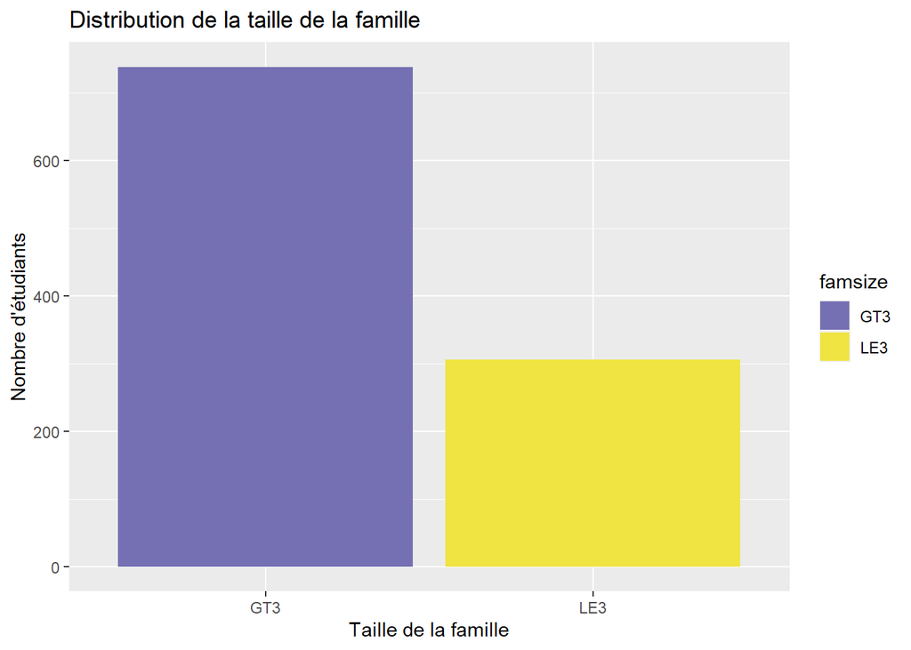

```r
# Distribution
ggplot(data = df, aes(x = famsize, fill = famsize)) +
  geom_bar() +
  labs(title = "Distribution de la taille de la famille",
       x = "Taille de la famille", y = "Nombre d'étudiants") +
  scale_fill_manual(values = c("#7570b3","#F0E442"))
```

```r
# Lien avec les notes
summary(lm(Moy ~ famsize,data=df))
```

```
##
## Call:
## lm(formula = Moy ~ famsize, data = df)
##
## Residuals:
##     Min      1Q  Median      3Q     Max
## -9.9096 -1.9096 -0.1391  2.1942  8.1942
##
## Coefficients:
##             Estimate Std. Error t value Pr(>|t|)
## (Intercept)  11.1391     0.1183   94.15   <2e-16 ***
## famsizeLE3    0.4371     0.2185    2.00   0.0457 *
## ---
## Signif. codes:  0 '***' 0.001 '**' 0.01 '*' 0.05 '.' 0.1 ' ' 1
##
## Residual standard error: 3.214 on 1042 degrees of freedom
## Multiple R-squared:  0.003825,   Adjusted R-squared:  0.002869
## F-statistic: 4.001 on 1 and 1042 DF,  p-value: 0.04573
```

```r
# Lien avec la réussite
chisq.test(df$famsize,df$RS)
```

```
##
##  Pearson's Chi-squared test with Yates' continuity correction
##
## data:  df$famsize and df$RS
## X-squared = 1.6006, df = 1, p-value = 0.2058
```

### Situation familliale : séparation des parents

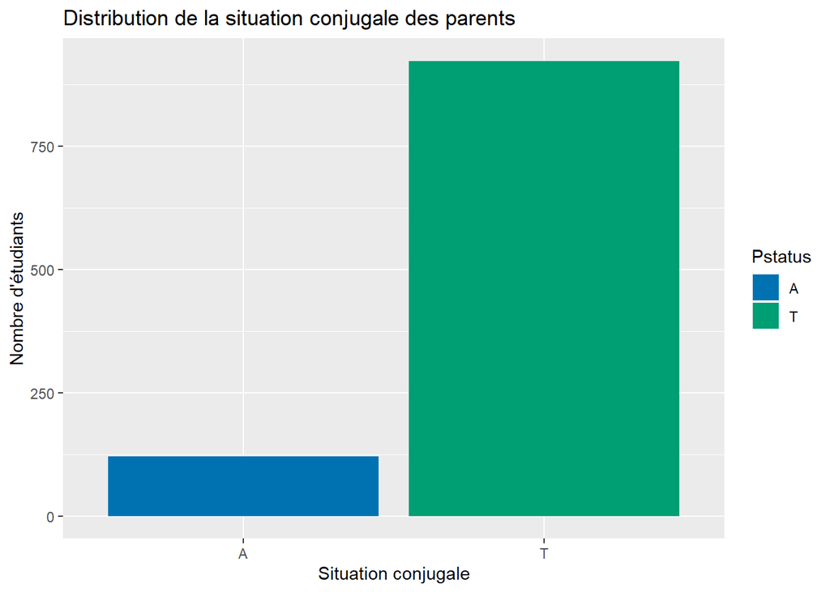

```r
# Distribution

ggplot(data = df, aes(x = Pstatus, fill = Pstatus)) +
  geom_bar() +
  scale_fill_manual(values = c("#0072B2", "#009E73")) +
  labs(title = "Distribution de la situation conjugale des parents",
       x = "Situation conjugale", y = "Nombre d'étudiants")
```

```r
# Lien avec les notes
summary(lm(Moy ~ Pstatus,data=df))
```

```
##
## Call:
## lm(formula = Moy ~ Pstatus, data = df)
##
## Residuals:
##      Min       1Q   Median       3Q      Max
## -10.0744  -1.9155   0.0845   2.0845   8.0845
##
## Coefficients:
##             Estimate Std. Error t value Pr(>|t|)
## (Intercept)  11.4077     0.2927   38.97   <2e-16 ***
## PstatusT     -0.1589     0.3113   -0.51     0.61
## ---
## Signif. codes:  0 '***' 0.001 '**' 0.01 '*' 0.05 '.' 0.1 ' ' 1
##
## Residual standard error: 3.22 on 1042 degrees of freedom
## Multiple R-squared:  0.0002499,  Adjusted R-squared:  -0.0007095
## F-statistic: 0.2605 on 1 and 1042 DF,  p-value: 0.6099
```

```r
# Lien avec la réussite
chisq.test(df$Pstatus,df$RS)
```

```
##
##  Pearson's Chi-squared test with Yates' continuity correction
##
## data:  df$Pstatus and df$RS
## X-squared = 0.60231, df = 1, p-value = 0.4377
```

### Travail des parents

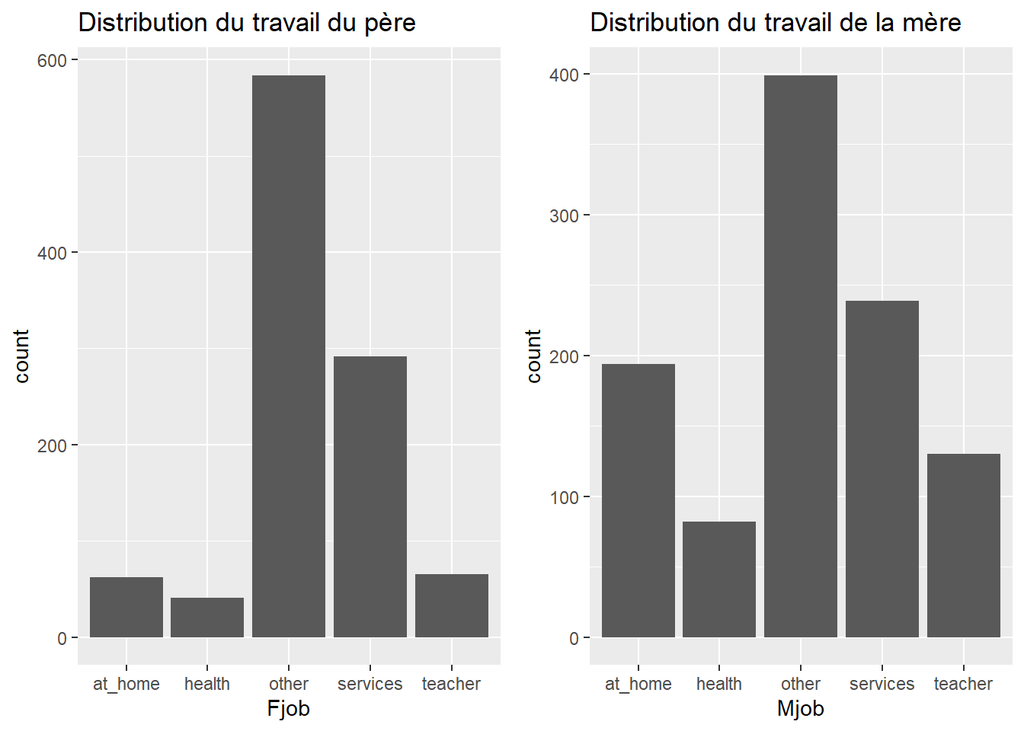

```r
#Distributions
g2=ggplot(data = df, aes(x = Mjob)) +
  geom_bar() +
  labs(title = "Distribution du travail de la mère") +
  scale_fill_manual(values = c("#7570b3","#0072B2", "#E69F00", "#009E73", "#F0E442"))

g1=ggplot(data = df, aes(x = Fjob)) +
  geom_bar() +
  labs(title="Distribution du travail du père") +
  scale_fill_manual(values = c("#7570b3","#0072B2", "#E69F00", "#009E73", "#F0E442"))

grid.arrange(g1, g2, ncol = 2)
```

```r
# Lien avec les notes
summary(lm(Moy ~ Medu+Fedu,data=df))
```

```
##
## Call:
## lm(formula = Moy ~ Medu + Fedu, data = df)
##
## Residuals:
##     Min      1Q  Median      3Q     Max
## -10.265  -1.732   0.068   2.126   7.852
##
## Coefficients:
##             Estimate Std. Error t value Pr(>|t|)
## (Intercept)   9.4233     0.2595  36.316  < 2e-16 ***
## Medu          0.5214     0.1125   4.635 4.02e-06 ***
## Fedu          0.2037     0.1150   1.771   0.0769 .
## ---
## Signif. codes:  0 '***' 0.001 '**' 0.01 '*' 0.05 '.' 0.1 ' ' 1
##
## Residual standard error: 3.133 on 1041 degrees of freedom
## Multiple R-squared:  0.05434,    Adjusted R-squared:  0.05252
## F-statistic: 29.91 on 2 and 1041 DF,  p-value: 2.344e-13
```

```r
# Lien avec la réussite
chisq.test(df$Mjob,df$RS)
```

```
##
##  Pearson's Chi-squared test
##
## data:  df$Mjob and df$RS
## X-squared = 18.127, df = 4, p-value = 0.001166
```

```r
chisq.test(df$Fjob,df$RS)
```

```
##
##  Pearson's Chi-squared test
##
## data:  df$Fjob and df$RS
## X-squared = 6.42, df = 4, p-value = 0.1699
```

### Les raisons du choix d’école

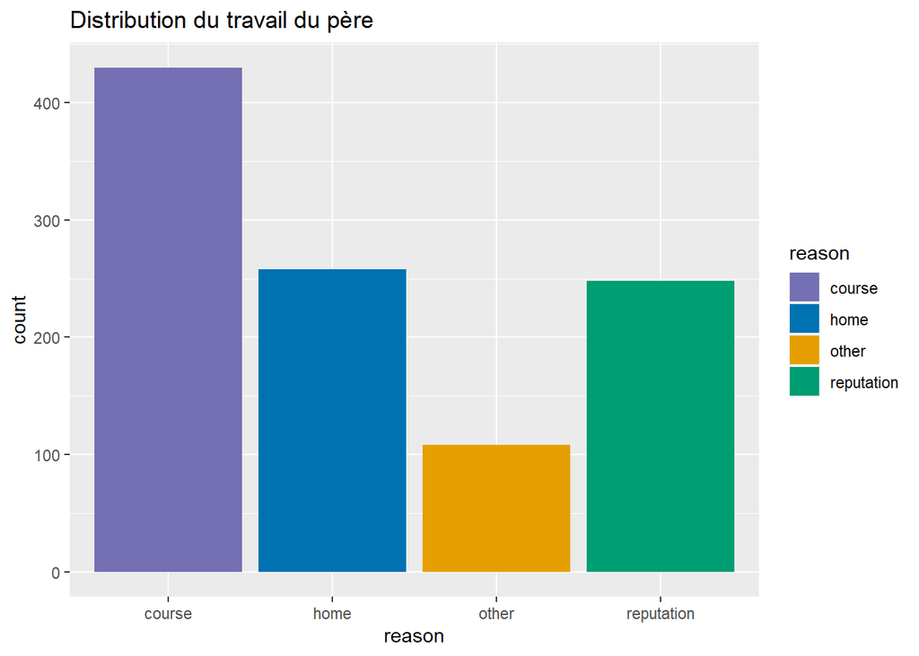

```r
# Distribution
ggplot(data = df, aes(x = reason, fill = reason)) +
  geom_bar() +
  labs(title="Distribution du travail du père") +
  scale_fill_manual(values = c("#7570b3","#0072B2", "#E69F00", "#009E73", "#F0E442"))
```

```r
# Lien avec les notes
summary(lm(Moy~ reason,data=df))
```

```
##
## Call:
## lm(formula = Moy ~ reason, data = df)
##
## Residuals:
##      Min       1Q   Median       3Q      Max
## -10.3858  -1.8791  -0.0052   2.1209   7.7876
##
## Coefficients:
##                  Estimate Std. Error t value Pr(>|t|)
## (Intercept)      10.87907    0.15372  70.771  < 2e-16 ***
## reasonhome        0.45943    0.25103   1.830   0.0675 .
## reasonother      -0.03956    0.34309  -0.115   0.9082
## reasonreputation  1.17335    0.25417   4.616 4.39e-06 ***
## ---
## Signif. codes:  0 '***' 0.001 '**' 0.01 '*' 0.05 '.' 0.1 ' ' 1
##
## Residual standard error: 3.188 on 1040 degrees of freedom
## Multiple R-squared:  0.02209,    Adjusted R-squared:  0.01927
## F-statistic: 7.832 on 3 and 1040 DF,  p-value: 3.587e-05
```

```r
# Lien avec la réussite
chisq.test(df$reason,df$RS)
```

```
##
##  Pearson's Chi-squared test
##
## data:  df$reason and df$RS
## X-squared = 14.63, df = 3, p-value = 0.002162
```

### Les relations

Il y a environ deux fois plus de jeunes célibataires que de jeunes en couple. On peut penser qu’être en couple réduit le temps passé à étudier et rajoute des distractions, donc il devrait avoir un impact négatif sur les notes. D’après le test de Fisher, la p-value est fortement inférieure à 5%, donc on rejette H0: il y a bien un lien entre situation romantique et notes, ce qui rejoint bien l’idée de départ. Il serait donc intéréssant d’étudier la distribution des notes selon la situation romantique. D’après les boxplots, les différences sont assez minimes, même si on peut aperçevoir que les notes des célibataires sont légèrement meilleures. Cependant, la présence de relation amoureuse n’a pas d’impact sur la réussite scolaire. Ainsi, être en couple fait baisser la moyenne mais n’est pas un facteur d’échec.

```r
# Distribution
gr1=ggplot(df, aes(x = romantic)) +
  geom_bar(fill = "steelblue") +
  labs(title = "Distribution des personnes en couple",
       x = "Couple", y = "Nombre d'étudiants")

# Lien avec les notes
summary(lm(Moy~ romantic,data=df))
```

```
##
## Call:
## lm(formula = Moy ~ romantic, data = df)
##
## Residuals:
##      Min       1Q   Median       3Q      Max
## -10.1486  -1.9455   0.1222   2.1847   7.8514
##
## Coefficients:
##             Estimate Std. Error t value Pr(>|t|)
## (Intercept)  11.4819     0.1236  92.871  < 2e-16 ***
## romanticyes  -0.6041     0.2074  -2.913  0.00366 **
## ---
## Signif. codes:  0 '***' 0.001 '**' 0.01 '*' 0.05 '.' 0.1 ' ' 1
##
## Residual standard error: 3.207 on 1042 degrees of freedom
## Multiple R-squared:  0.008077,   Adjusted R-squared:  0.007125
## F-statistic: 8.485 on 1 and 1042 DF,  p-value: 0.003658
```

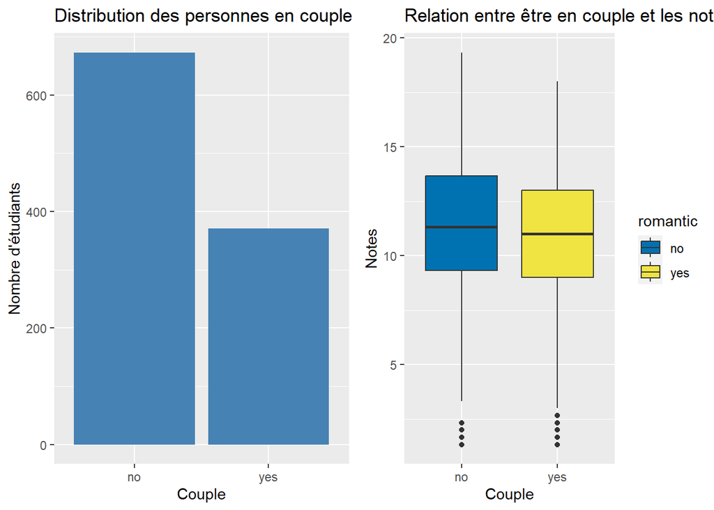

```r
yes = df$Moy[df$romantic=='yes']
no = df$Moy[df$romantic=='no']

# Boxplot des notes
gr2=ggplot(data = df, aes(x = romantic, y = Moy, fill = romantic)) +
  geom_boxplot() +
  scale_fill_manual(values = c("#0072B2", "#F0E442")) +
  labs(title = "Relation entre être en couple et les notes",
       x = "Couple", y = "Notes")

grid.arrange(gr1, gr2, ncol = 2)
```

```r
# Lien avec la réussite
chisq.test(df$romantic,df$RS)
```

```
##
##  Pearson's Chi-squared test with Yates' continuity correction
##
## data:  df$romantic and df$RS
## X-squared = 2.5646, df = 1, p-value = 0.1093
```

### Volonté de faire des études supérieures

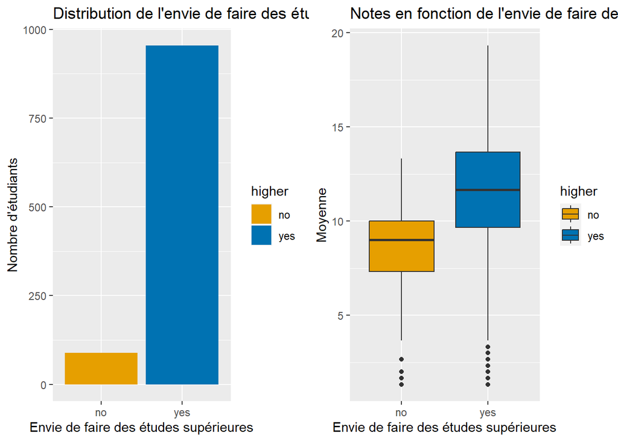

```r
# distribution
g1=ggplot(df, aes(x = higher, fill = higher)) +
  geom_bar() +
  labs(title = "Distribution de l'envie de faire des études supérieures",
       x = "Envie de faire des études supérieures", y = "Nombre d'étudiants") +
  scale_fill_manual(values = c("#E69F00", "#0072B2"))

# Boxplot des notes en fonction de l'envie de faire des études supérieures
g2=ggplot(df, aes(x = higher, y = Moy, fill = higher)) +
  geom_boxplot() +
  labs(title = "Notes en fonction de l'envie de faire des études supérieures",
       x = "Envie de faire des études supérieures", y = "Moyenne") +
  scale_fill_manual(values = c("#E69F00", "#0072B2"))

grid.arrange(g1, g2, ncol = 2)
```

```r
# Lien avec les notes
summary(lm(Moy ~ higher,data=df))
```

```
##
## Call:
## lm(formula = Moy ~ higher, data = df)
##
## Residuals:
##      Min       1Q   Median       3Q      Max
## -10.1930  -1.8597   0.1403   2.1403   7.8070
##
## Coefficients:
##             Estimate Std. Error t value Pr(>|t|)
## (Intercept)   8.4869     0.3293  25.775   <2e-16 ***
## higheryes     3.0395     0.3443   8.829   <2e-16 ***
## ---
## Signif. codes:  0 '***' 0.001 '**' 0.01 '*' 0.05 '.' 0.1 ' ' 1
##
## Residual standard error: 3.106 on 1042 degrees of freedom
## Multiple R-squared:  0.0696, Adjusted R-squared:  0.06871
## F-statistic: 77.95 on 1 and 1042 DF,  p-value: < 2.2e-16
```

```r
yes = df$Moy[df$higher=='yes']
no = df$Moy[df$higher=='no']

# Lien avec la réussite
chisq.test(df$higher,df$RS)
```

```
##
##  Pearson's Chi-squared test with Yates' continuity correction
##
## data:  df$higher and df$RS
## X-squared = 59.569, df = 1, p-value = 1.181e-14
```

### Activités extrascolaires

On a autant d’élèves qui pratiquent des activités extrascolaires que d’élèves qui n’en pratiquent pas, ce qui est plutôt intéréssant. De plus, le test de Fisher indique plutôt qu’il n’y a pas de liens entre les activités extrascolaires et les notes, ce qui est plutôt surprenant étant donné que l’on aurait tendance à penser que les étudiants ayant des activités, ont moins de temps pour étudier. Dans la même lignée, les activités sont plutôt indépendates de la réussite d’après le test de Chi2.

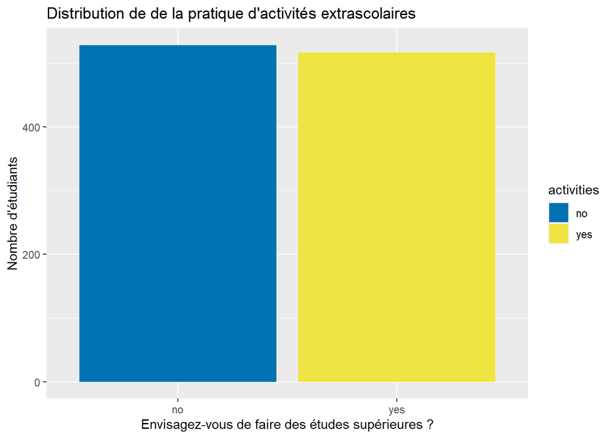

```r
# Distribution
ggplot(df, aes(x = activities, fill = activities)) +
  geom_bar() +
  labs(title = "Distribution de de la pratique d'activités extrascolaires",
       x = "Envisagez-vous de faire des études supérieures ?",
       y = "Nombre d'étudiants") +
  scale_fill_manual(values = c("#0072B2", "#F0E442"))
```

```r
# Lien avec les notes
summary(lm(Moy ~ activities,data=df))
```

```
##
## Call:
## lm(formula = Moy ~ activities, data = df)
##
## Residuals:
##      Min       1Q   Median       3Q      Max
## -10.1085  -2.0966  -0.0966   2.2248   7.8915
##
## Coefficients:
##               Estimate Std. Error t value Pr(>|t|)
## (Intercept)    11.0966     0.1399  79.292   <2e-16 ***
## activitiesyes   0.3453     0.1991   1.734   0.0831 .
## ---
## Signif. codes:  0 '***' 0.001 '**' 0.01 '*' 0.05 '.' 0.1 ' ' 1
##
## Residual standard error: 3.216 on 1042 degrees of freedom
## Multiple R-squared:  0.002879,   Adjusted R-squared:  0.001922
## F-statistic: 3.008 on 1 and 1042 DF,  p-value: 0.08313
```

```r
# Lien avec la réussite
chisq.test(df$activities,df$RS)
```

```
##
##  Pearson's Chi-squared test with Yates' continuity correction
##
## data:  df$activities and df$RS
## X-squared = 1.1969, df = 1, p-value = 0.274
```

### Cours supplémentaires

Il y a bien plus d’élèves qui ne suivent pas de cours supplémentaires que d’élèves qui en suivent. Cett distributution est cohérente avec l’idée qu’on oeut se faire. Le test de Fisher indique plutôt que les suivis de cours supplémentaires n’a pas d’impact sur la moyenne. Cependant, d’après le test du Chi2, le suivi de cours supplémentare est bien lié à la réussite scolaire.

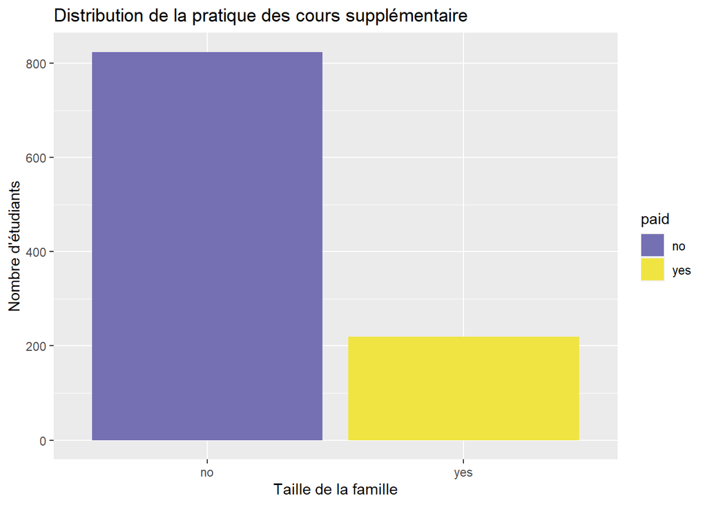

```r
# Distribution
ggplot(data = df, aes(x =paid, fill = paid)) +
  geom_bar() +
  labs(title = "Distribution de la pratique des cours supplémentaire",
       x = "Taille de la famille", y = "Nombre d'étudiants") +
  scale_fill_manual(values = c("#7570b3","#F0E442"))
```

```r
#barplot(table(df$paid),main="Distribution de la pratique des cours supplémentaires")

# Lien avec la moyenne
summary(lm(Moy ~ paid,data=df))
```

```
##
## Call:
## lm(formula = Moy ~ paid, data = df)
##
## Residuals:
##     Min      1Q  Median      3Q     Max
## -9.9951 -1.9951  0.0049  2.0049  8.0049
##
## Coefficients:
##             Estimate Std. Error t value Pr(>|t|)
## (Intercept)  11.3285     0.1121  101.05   <2e-16 ***
## paidyes      -0.2906     0.2442   -1.19    0.234
## ---
## Signif. codes:  0 '***' 0.001 '**' 0.01 '*' 0.05 '.' 0.1 ' ' 1
##
## Residual standard error: 3.218 on 1042 degrees of freedom
## Multiple R-squared:  0.001357,   Adjusted R-squared:  0.0003986
## F-statistic: 1.416 on 1 and 1042 DF,  p-value: 0.2344
```

```r
# Lien avec la réussite
chisq.test(df$paid,df$RS)
```

```
##
##  Pearson's Chi-squared test with Yates' continuity correction
##
## data:  df$paid and df$RS
## X-squared = 4.4704, df = 1, p-value = 0.03449
```

## Les variables quantitatives

```r
data=df
data_quanti=data[c(3,7,8,13,14,15,25,26,27,28,29,30,31,32,33)]
data_quanti_mat=df.mat[c(3,7,8,13,14,15,25,26,27,28,29,30,31,32,33)]
data_quanti_por=df.por[c(3,7,8,13,14,15,25,26,27,28,29,30,31,32,33)]
head(data_quanti)
```

```
##   age Medu Fedu traveltime studytime failures freetime goout Dalc Walc health
## 1  18    4    4          2         2        0        3     4    1    1      3
## 2  17    1    1          1         2        0        3     3    1    1      3
## 3  15    1    1          1         2        3        3     2    2    3      3
## 4  15    4    2          1         3        0        2     2    1    1      5
## 5  16    3    3          1         2        0        3     2    1    2      5
## 6  16    4    3          1         2        0        4     2    1    2      5
##   absences G1 G2 G3
## 1        6  5  6  6
## 2        4  5  5  6
## 3       10  7  8 10
## 4        2 15 14 15
## 5        4  6 10 10
## 6       10 15 15 15
```

### L’âge des élèves

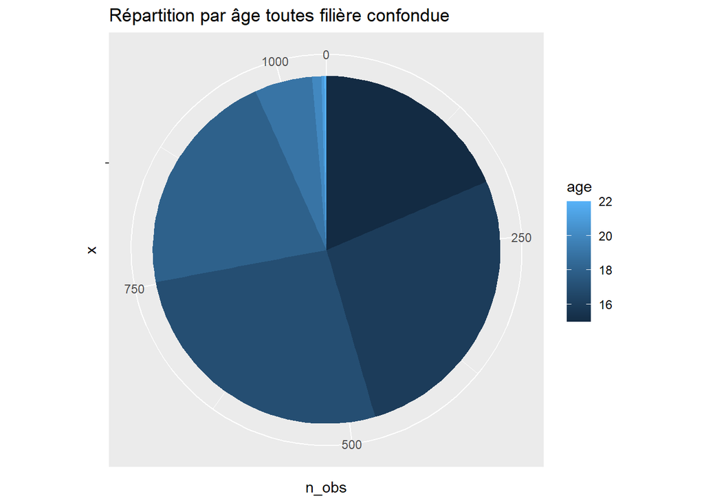

```r
attach(data_quanti)
data_age=data_quanti

data_age=summarise(group_by(data_age,age),n_obs=n()) #on groupe par âge avec le nombre de personnes dans chaque classe

#création du camembert
ggplot(data = data_age, aes(x = "", y = n_obs, fill = age)) +
  geom_bar(stat = "identity", width = 1) +
  coord_polar(theta = "y") +
  labs(title = "Répartition par âge toutes filière confondue")
```

La couleur la plus claire correspond à l’âge le plus grand (22 ans), dès que l’on passe à une couleur plus foncée, on diminue l’âge de 1. On voit clairement ici que la majorité des étudiants ont entre 15 et 19 ans.

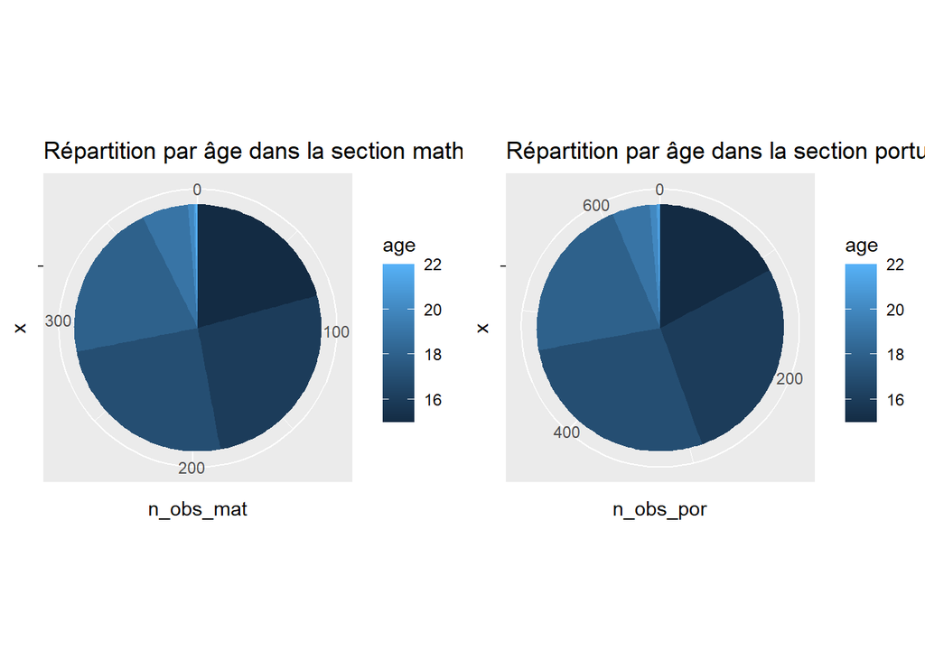

```r
data_age_mat=data_quanti_mat
data_age_por=data_quanti_por

data_age_mat=summarise(group_by(data_age_mat,age),n_obs_mat=n()) #on groupe par âge avec le nombre de personnes dans chaque classe
data_age_por=summarise(group_by(data_age_por,age),n_obs_por=n())

#création du camembert
p1=ggplot(data = data_age_mat, aes(x = "", y = n_obs_mat, fill = age)) +
  geom_bar(stat = "identity", width = 1) +
  coord_polar(theta = "y") +
  labs(title = "Répartition par âge dans la section maths")

p2=ggplot(data = data_age_por, aes(x = "", y = n_obs_por, fill = age)) +
  geom_bar(stat = "identity", width = 1) +
  coord_polar(theta = "y") +
  labs(title = "Répartition par âge dans la section portugais")

grid.arrange(p1, p2, ncol = 2)
```

On voit que la répartiion semble être la grosiièrement la même, en effet:

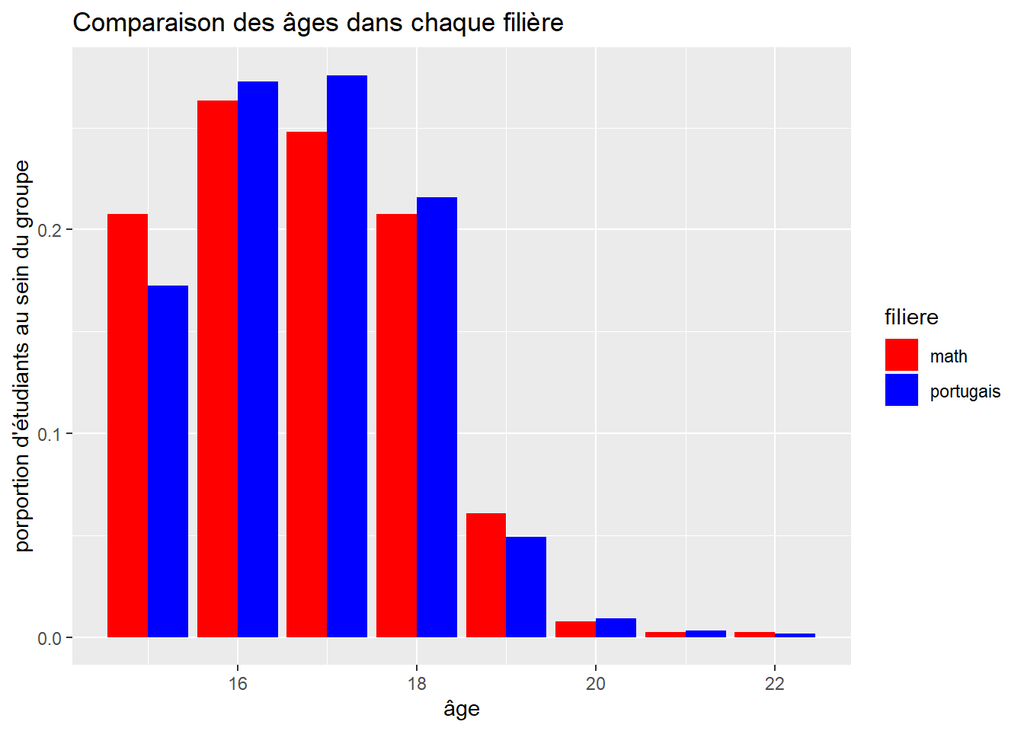

```r
data_age_mat <- data_age_mat %>%
  mutate(proportion = n_obs_mat / sum(n_obs_mat))

data_age_por <- data_age_por %>%
  mutate(proportion = n_obs_por / sum(n_obs_por))

#on renome de la même manière les colonnes du nombre d'étudiants pour chaque obersvation
data_age_mat$filiere=c(rep("math",nrow(data_age_mat)))
data_age_por$filiere=c(rep("portugais",nrow(data_age_por)))
colnames(data_age_mat)[colnames(data_age_mat) == "n_obs_mat"] <- "n_obs"
colnames(data_age_por)[colnames(data_age_por) == "n_obs_por"] <- "n_obs"

#on concatène les deux datas frame
data_age=rbind(data_age_mat,data_age_por)

#Création du graphique

ggplot(data_age, aes(x = age, y = proportion, fill = filiere)) +
  geom_bar(stat = "identity", position = position_dodge()) +
  labs(title = "Comparaison des âges dans chaque filière", x ="âge", y = "porportion d'étudiants au sein du groupe") +
  scale_fill_manual(values = c("red", "blue"))
```

On voit que la répartion d’âge est la même dans chaque filière

### Quantité de travail

[figure not shown]

```r
data_stud=data_quanti
data_stud=summarise(group_by(data_stud,studytime),n_obs=n()) #on groupe par temps d'étude par semaine

data_stud$studytime[data_stud$studytime == 1] <- "<2 hours"
data_stud$studytime[data_stud$studytime == 2] <- "2 to 5 hours"
data_stud$studytime[data_stud$studytime == 3] <- "5 to 10 hours"
data_stud$studytime[data_stud$studytime == 4] <- ">10 hours"


ggplot(data_stud, aes(x = "", y = n_obs, fill = factor(studytime))) +
  geom_bar(stat = "identity", width = 1) +
  coord_polar(theta = "y") +
  labs(title = "Répartition des temps d'étude toutes filières confondues") +
  scale_fill_discrete(name = "Temps d'étude", labels = c("<=2 hours", "2 to 5 hours", "5 to 10 hours", ">10 hours"))
```

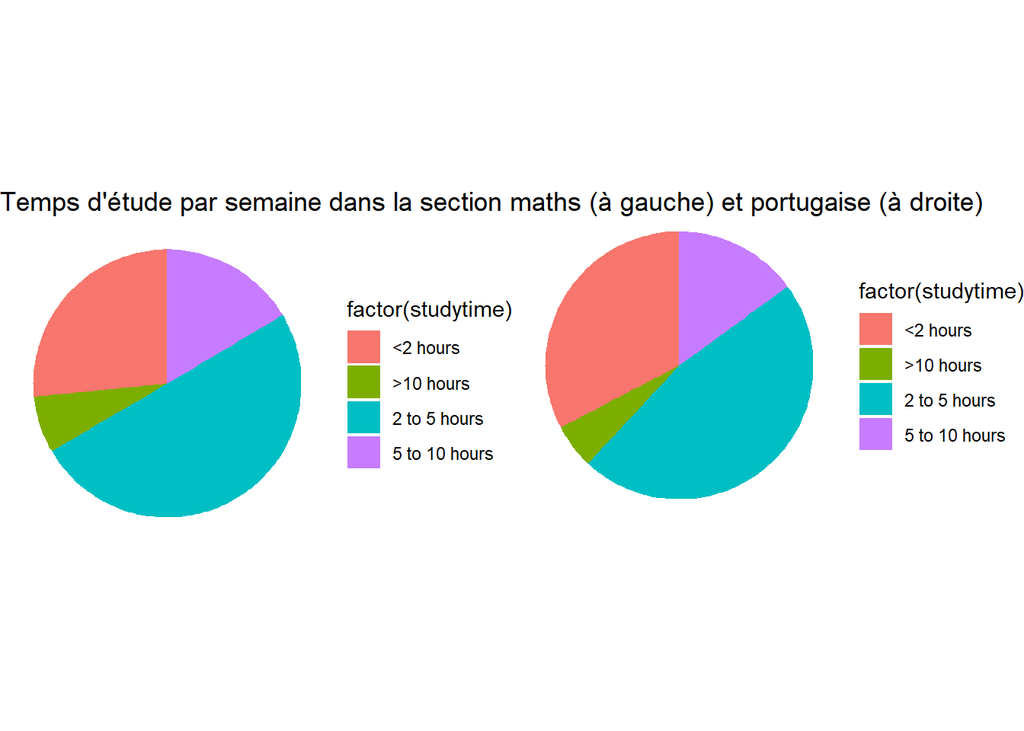

```r
#creation data frame stud pour le groupe portugais
data_stud_por=data_quanti_por
data_stud_por=summarise(group_by(data_stud_por,studytime),n_obs_por=n()) #on groupe par temps d'étude par semaine

data_stud_por$studytime[data_stud_por$studytime == 1] <- "<2 hours"
data_stud_por$studytime[data_stud_por$studytime == 2] <- "2 to 5 hours"
data_stud_por$studytime[data_stud_por$studytime == 3] <- "5 to 10 hours"
data_stud_por$studytime[data_stud_por$studytime == 4] <- ">10 hours"

#creation data frame stud pour le groupe mat b
data_stud_mat=data_quanti_mat
data_stud_mat=summarise(group_by(data_stud_mat,studytime),n_obs_mat=n()) #on groupe par temps d'étude par semaine

data_stud_mat$studytime[data_stud_mat$studytime == 1] <- "<2 hours"
data_stud_mat$studytime[data_stud_mat$studytime == 2] <- "2 to 5 hours"
data_stud_mat$studytime[data_stud_mat$studytime == 3] <- "5 to 10 hours"
data_stud_mat$studytime[data_stud_mat$studytime == 4] <- ">10 hours"

#création des camemberts pour les deux sections
p1=ggplot() +
  # Premier camembert
  geom_bar(data = data_stud_mat, aes(x = "", y = n_obs_mat, fill = factor(studytime)), stat = "identity", width = 1) +
  coord_polar(theta = "y") +
  theme_void() +
  labs(title = "Temps d'étude par semaine dans la section maths (à gauche) et portugaise (à droite)")

  # Deuxième camembert
p2=ggplot() +
  geom_bar(data = data_stud_por, aes(x = "", y = n_obs_por, fill = factor(studytime)), stat = "identity", width = 1) +
  coord_polar(theta = "y") +
  theme_void()

grid.arrange(p1, p2, ncol = 2)
```

```r
data_stud_mat
```

```
## # A tibble: 4 x 2
##   studytime     n_obs_mat
##   <chr>             <int>
## 1 <2 hours            105
## 2 2 to 5 hours        198
## 3 5 to 10 hours        65
## 4 >10 hours            27
```

On voit qu’il y a plus de personnes qui travaillent moins de deux heures par semaine dans la section portiguaise tandis qu’il y a moins de personnes qui travaillent plus de 10h00 dans cette même section. Le nombre d’étudiants travaillant entre 5 et 10 heures semble être a peu près le même. En effet:

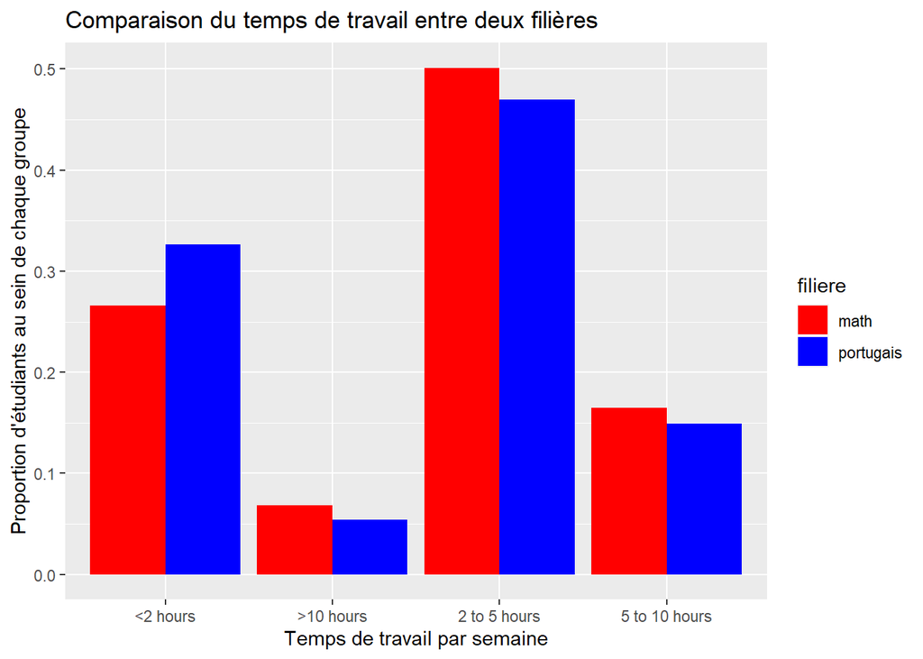

```r
#on calcul la porportion pour pouvoir comparer
data_stud_mat <- data_stud_mat %>%
  mutate(proportion = n_obs_mat / sum(n_obs_mat))

data_stud_por <- data_stud_por %>%
  mutate(proportion = n_obs_por / sum(n_obs_por))

#on renome de la même manière les colonnes du nombre d'étudiants pour chaque obersvation
data_stud_mat$filiere=c(rep("math",nrow(data_stud_mat)))
data_stud_por$filiere=c(rep("portugais",nrow(data_stud_por)))
colnames(data_stud_mat)[colnames(data_stud_mat) == "n_obs_mat"] <- "n_obs"
colnames(data_stud_por)[colnames(data_stud_por) == "n_obs_por"] <- "n_obs"

#on concatène les deux datas frame
data_stud=rbind(data_stud_mat,data_stud_por)

#Création du graphique

ggplot(data_stud, aes(x = studytime, y = proportion, fill = filiere)) +
  geom_bar(stat = "identity", position = position_dodge()) +
  labs(title = "Comparaison du temps de travail entre deux filières", x = "Temps de travail par semaine", y = "Proportion d'étudiants au sein de chaque groupe") +
  scale_fill_manual(values = c("red", "blue"))
```

On s’aperçoit donc que les élèves dans la filière mathématiques travaillent plus

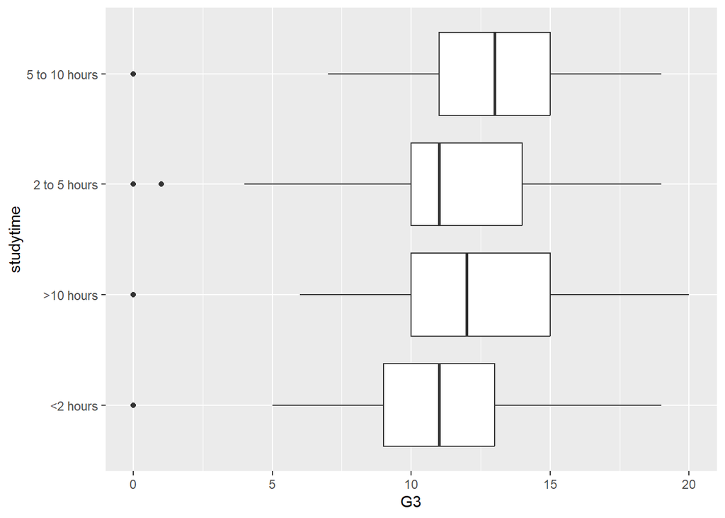

```r
data_quanti$studytime[data_quanti$studytime == 1] <- "<2 hours"
data_quanti$studytime[data_quanti$studytime == 2] <- "2 to 5 hours"
data_quanti$studytime[data_quanti$studytime == 3] <- "5 to 10 hours"
data_quanti$studytime[data_quanti$studytime == 4] <- ">10 hours"

ggplot(data_quanti, aes(x = G3, y = studytime)) +
  geom_boxplot()
```

On voit que globalement, les élèves qui travaillent plus ont de meilleures notes (comportement bizarre à vérifier)

### Absences des étudiants

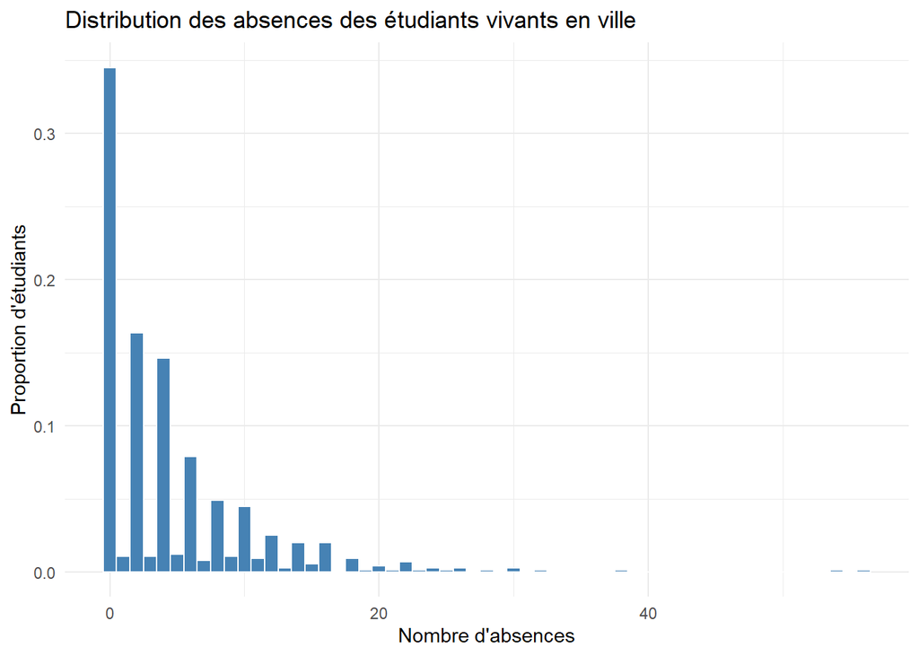

```r
ggplot(df[df$address == 'U',], aes(x=absences)) +
  geom_histogram(aes(y = ..count.. / sum(..count..)), binwidth=1, fill="steelblue", color="white") +
  labs(title="Distribution des absences des étudiants vivants en ville",
       x="Nombre d'absences", y="Proportion d'étudiants") +
  theme_minimal()
```

### Santé des étudiants

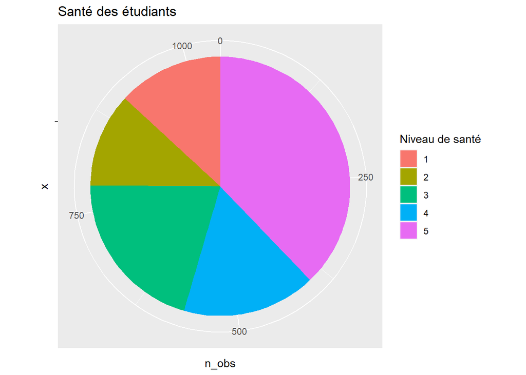

```r
data_health=data_quanti
data_health=summarise(group_by(data_health,health),n_obs=n())


ggplot(data_health, aes(x = "", y = n_obs, fill = factor(health))) +
  geom_bar(stat = "identity", width = 1) +
  coord_polar(theta = "y") +
  labs(title = "Santé des étudiants") +
  scale_fill_discrete(name = "Niveau de santé", labels = c(1,2,3,4,5))
```

On voit que la plupart des étudiant sont en bonne santé

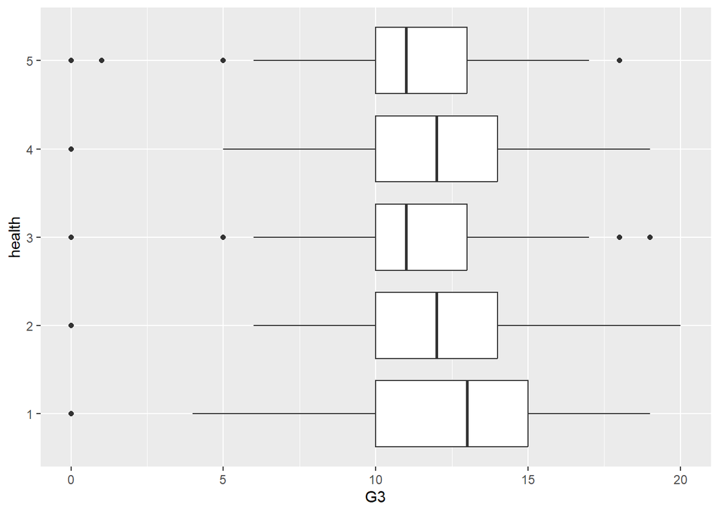

```r
data_quanti$health=factor(data_quanti$health)
ggplot(data_quanti, aes(x = G3, y = health)) +
  geom_boxplot()
```

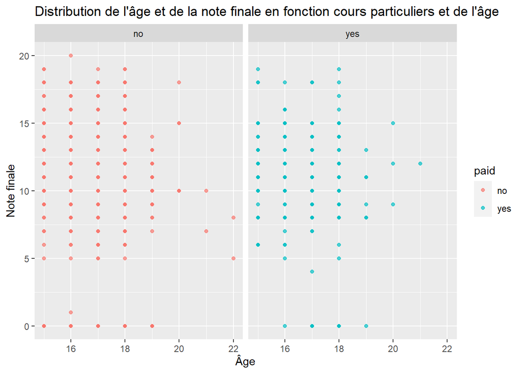

```r
ggplot(df, aes(x = age, y = G3, color = paid)) +
  geom_point(alpha = 0.7) +
  facet_wrap(~paid) +
  labs(title = "Distribution de l'âge et de la note finale en fonction cours particuliers et de l'âge",
       x = "Âge", y = "Note finale")
```

Curieusement, les résultats semblent meilleur pour ceux qui n’on pas pris de cours

# 4. Machine Learning : Classification de la réussite scolaire

Dans cette partie, nous nous concentrons sur la mise en place de méthodes de classification afin de prédire la variable RS (réussite scolaire). Nous nous intéresserons essentiellement à la comparaison des résultats de chacune des méthodes. Les méthodes utilisées seront évaluées avec leur accuracy et leur courbe ROC.

## a) Séparation du jeu de données

Ici, nous découpons notre dataset en jeu d’entraînement et jeu de test. Le ratio utilisé est $\frac{1}{5}$ pour le jeu de test. Tout d’abord on modifie notre jeu de données pour le préparer pour la classification en retirant les notes.

```r
# Suppresion des colonnes
X = subset(df, select = -c(G1,G2,G3,Moy) )

set.seed(1)
n <- nrow(X)
p <- ncol(X)-1
test.ratio <- .2 # ratio of test/train samples
n.test <- round(n*test.ratio)
n.test
```

```
## [1] 209
```

```r
tr <- sample(1:n,n.test)
df.test <- X[tr,]
df.train <- X[-tr,]
```

## b) LDA

```r
res_lda=lda(df.train$RS ~., data=df.train)
pred_lda <- predict(res_lda,newdata=df.test)$posterior[,2]

# Table de confusion
table(df.test$RS,predict(res_lda,newdata=df.test)$class)
```

```
##
##         FALSE TRUE
##   FALSE    27   39
##   TRUE      7  136
```

```r
# Courbe ROC
ROC_lda <- roc(df.test$RS, pred_lda)
```

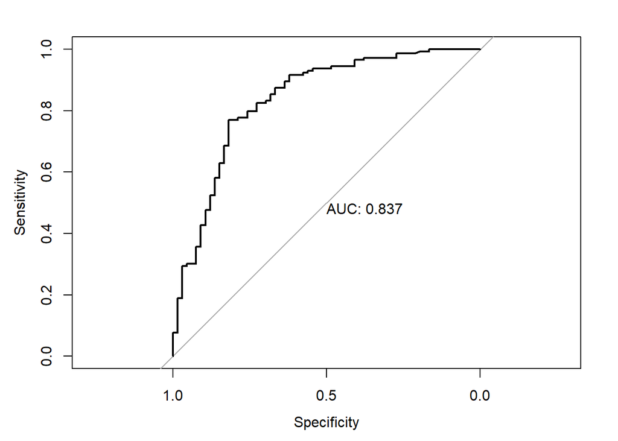

```r
plot(ROC_lda, print.auc=TRUE,  print.auc.y = 0.5)
```

```r
ROC_lda$auc
```

```
## Area under the curve: 0.8368
```

```r
# Accuracy
accuracy_lda = mean(df.test$RS==predict(res_lda,newdata=df.test)$class)
print("accuracy lda = ")
```

```
## [1] "accuracy lda = "
```

```r
print(accuracy_lda)
```

```
## [1] 0.7799043
```

## c) QDA

```r
res_qda = qda(df.train$RS~., data=df.train)
pred_qda <- predict(res_qda,newdata=df.test)$posterior[,2]

# Table de confusion
table(df.test$RS,predict(res_qda,newdata=df.test)$class)
```

```
##
##         FALSE TRUE
##   FALSE    41   25
##   TRUE     16  127
```

```r
# Courbe ROC
ROC_qda <- roc(df.test$RS, pred_qda)
```

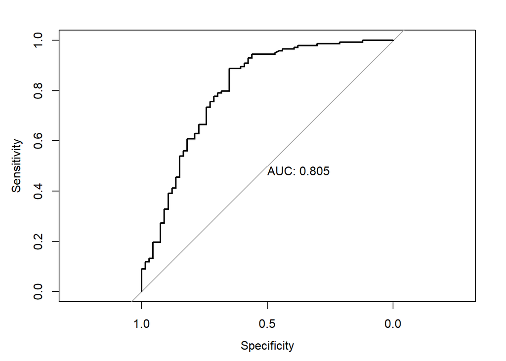

```r
plot(ROC_qda, print.auc=TRUE,  print.auc.y = 0.5)
```

```r
ROC_qda$auc
```

```
## Area under the curve: 0.805
```

```r
# Accuracy
accuracy_qda = mean(df.test$RS==predict(res_qda,newdata=df.test)$class)
print("accuracy qda = ")
```

```
## [1] "accuracy qda = "
```

```r
print(accuracy_qda)
```

```
## [1] 0.8038278
```

## d) Stepwise

```r
stepwise_lda=stepclass(RS~., data=df.train, method="lda", direction="backward")
```

```
##  `stepwise classification', using 10-fold cross-validated correctness rate of method lda'.
```

```
## 835 observations of 30 variables in 2 classes; direction: backward
```

```
## stop criterion: improvement less than 5%.
```

```
## correctness rate: 0;  starting variables (30): school, sex, age, address, famsize, Pstatus, Medu, Fedu, Mjob, Fjob, reason, guardian, traveltime, studytime, failures, schoolsup, famsup, paid, activities, nursery, higher, internet, romantic, famrel, freetime, goout, Dalc, Walc, health, absences
```

[output not shown]

[output cut: 31 more lines]

[output not shown]

```
##
##  hr.elapsed min.elapsed sec.elapsed
##        0.00        0.00        2.14
```

```r
stepwise_lda
```

```
## method      : lda
## final model : RS ~ school + sex + age + address + famsize + Pstatus + Medu +
##     Fedu + Mjob + Fjob + reason + guardian + traveltime + studytime +
##     failures + schoolsup + famsup + paid + activities + nursery +
##     higher + internet + romantic + famrel + freetime + goout +
##     Dalc + Walc + health + absences
## <environment: 0x00000000249cb490>
##
## correctness rate = 0
```

```r
res_stepwise_lda = lda(stepwise_lda$formula, data=df.train)

pred_lda_step <- predict(res_stepwise_lda,newdata=df.test)$posterior[,2]

# Table de confusion
table(df.test$RS, predict(res_stepwise_lda,newdata=df.test)$class)
```

```
##
##         FALSE TRUE
##   FALSE    27   39
##   TRUE      7  136
```

```r
# Courbe ROC
ROC_lda_step <- roc(df.test$RS, pred_lda)
```

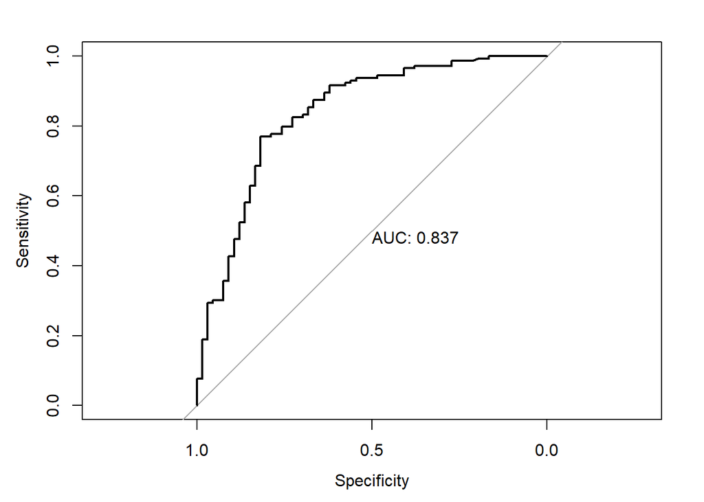

```r
plot(ROC_lda_step, print.auc=TRUE,  print.auc.y = 0.5)
```

```r
ROC_lda_step$auc
```

```
## Area under the curve: 0.8368
```

```r
# Accuracy
accuracy_lda_stepwise = mean(df.test$RS== predict(res_stepwise_lda,newdata=df.test)$class)
print("accuracy lda stepwise = ")
```

```
## [1] "accuracy lda stepwise = "
```

```r
print(accuracy_lda_stepwise)
```

```
## [1] 0.7799043
```

## e) Random Forest

```r
res_RF <- randomForest(RS~.,df.train)
res_RF
```

```
##
## Call:
##  randomForest(formula = RS ~ ., data = df.train)
##                Type of random forest: classification
##                      Number of trees: 500
## No. of variables tried at each split: 5
##
##         OOB estimate of  error rate: 28.62%
## Confusion matrix:
##       FALSE TRUE class.error
## FALSE    93  162   0.6352941
## TRUE     77  503   0.1327586
```

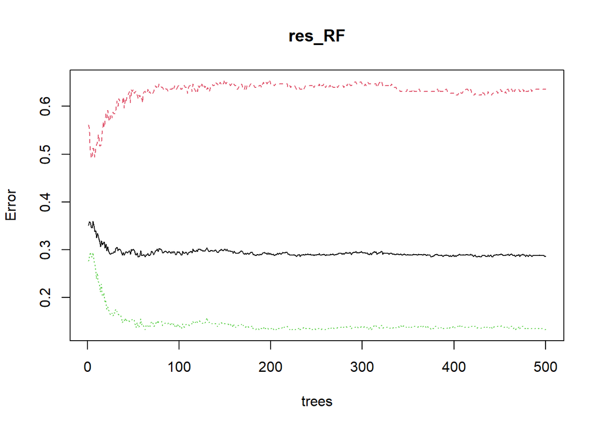

```r
plot(res_RF)
```

```r
## prédiction :
pred_RF <- predict(res_RF,newdata=df.test)

## Table confusion et accuracy :
table(df.test$RS, predict(res_RF,newdata=df.test,type="class"))
```

```
##
##         FALSE TRUE
##   FALSE    31   35
##   TRUE     13  130
```

```r
## aire sous courbe ROC
pred_RF = predict(res_RF, df.test, type="prob")[,2]
ROC_RF <- roc(df.test$RS, pred_RF)
ROC_RF$auc
```

```
## Area under the curve: 0.8281
```

```r
## Accuracy
accuracy_RF = mean(df.test$RS==predict(res_RF,newdata=df.test,type="class"))
print("accuracy RF = ")
```

```
## [1] "accuracy RF = "
```

```r
print(accuracy_RF)
```

```
## [1] 0.7703349
```

## f) CART

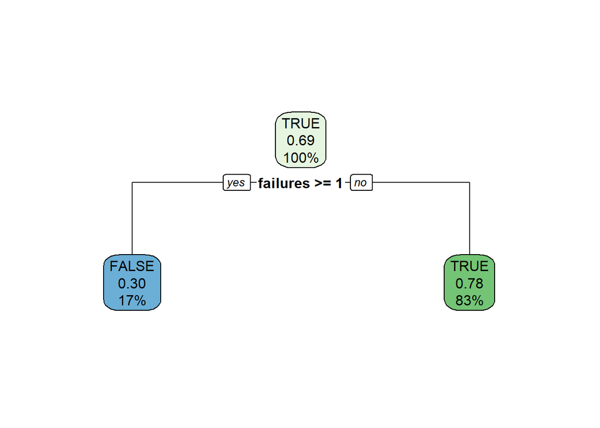

```r
arbre = rpart(df.train$RS~.,df.train,control=rpart.control(minsplit=5,cp=0.025))
cp.opt = arbre$cptable[which.min(arbre$cptable[, "xerror"]), "CP"]
res_cart = prune(arbre,cp=cp.opt)
rpart.plot(res_cart)
```

```r
## prédiction :
pred_cart <- predict(res_cart,newdata=df.test)[,2]

## Table confusion et accuracy :
table(df.test$RS, predict(res_cart,newdata=df.test,type="class"))
```

```
##
##         FALSE TRUE
##   FALSE    29   37
##   TRUE     10  133
```

```r
## aire sous courbe ROC
pred_cart = predict(res_cart, df.test, type="prob")[,2]
ROC_cart <- roc(df.test$RS, pred_cart)
ROC_cart$auc
```

```
## Area under the curve: 0.6847
```

```r
## Accuracy
accuracy_cart = mean(df.test$RS==predict(res_cart,newdata=df.test,type="class"))
print("accuracy cart = ")
```

```
## [1] "accuracy cart = "
```

```r
print(accuracy_cart)
```

```
## [1] 0.7751196
```

8. Adaboost

```r
fit.adaboost=gbm(as.numeric(RS)-1 ~., df.train, distribution = "adaboost")
fit.adaboost
```

```
## gbm(formula = as.numeric(RS) - 1 ~ ., distribution = "adaboost",
##     data = df.train)
## A gradient boosted model with adaboost loss function.
## 100 iterations were performed.
## There were 30 predictors of which 22 had non-zero influence.
```

```r
### Calibrer B=n.tree par cross-validation :
fit.adaboost=gbm(as.numeric(RS)-1 ~., df.train, distribution = "adaboost",cv.folds = 5, shrinkage = 0.01, n.trees=3000)
gbm.perf(fit.adaboost)
```

```
## [1] 649
```

```r
B.opt = gbm.perf(fit.adaboost, method="cv")
```

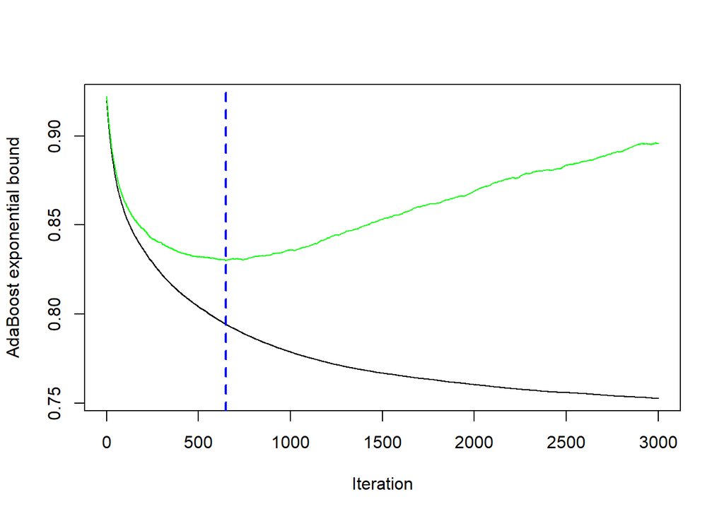

```r
## prédiction :
pred_adaboost = predict(fit.adaboost, newdata=df.test, type = "response", n.trees = B.opt)
class = 1*(pred_adaboost>1/2)

## Table confusion et accuracy :
table(df.test$RS, class)
```

```
##        class
##           0   1
##   FALSE  27  39
##   TRUE    8 135
```

```r
## Accuracy
accuracy_adaboost = mean(as.numeric(df.test$RS)-1==class)
print("accuracy adaboost = ")
```

```
## [1] "accuracy adaboost = "
```

```r
print(accuracy_adaboost)
```

```
## [1] 0.7751196
```

```r
## aire sous courbe ROC
ROC_adaboost <- roc(df.test$RS, pred_adaboost)
ROC_adaboost$auc
```

```
## Area under the curve: 0.8332
```

## i) Regression Logistique

```r
### Modèle
logit.train <- glm(RS ~ ., family = binomial , data=df.train)

## prédiction :
pred_logit <- predict(logit.train,newdata=df.test)
class = 1*(pred_logit>1/2)

## Table confusion et accuracy :
table(df.test$RS, class)
```

```
##        class
##           0   1
##   FALSE  43  23
##   TRUE   19 124
```

```r
## aire sous courbe ROC
ROC_logit <- roc(df.test$RS, pred_logit)
## Accuracy
accuracy_logit = mean(as.numeric(df.test$RS)-1==class)
print("accuracy regression logistique = ")
```

```
## [1] "accuracy regression logistique = "
```

```r
print(accuracy_logit)
```

```
## [1] 0.7990431
```

```r
ROC_logit$auc
```

```
## Area under the curve: 0.8295
```

```r
# # régression logistique Lasso
# library(glmnet)
# res_Lasso <- glmnet(as.matrix(df.train[,-1]),df.train$RS,family='binomial')
# plot(res_Lasso, label = TRUE)  # en abscisse : norme des coefficients
# plot(res_Lasso, xvar = "lambda", label = TRUE) # en abscisse : log(lambda)
# # sum(coef(res_Lasso, s=exp())!=0)
#
# cvLasso <- cv.glmnet(as.matrix(df.train[,-1]),df.train$RS,family="binomial", type.measure = "class")
# plot(cvLasso)
# cvLasso$lambda.min
# coef(res_Lasso, s=cvLasso$lambda.min)
#
# #prédiction
# class_logit_lasso=predict(cvLasso, newx = as.matrix(df.test[,-1]), s = 'lambda.min', type = "class")
#
# #Table de confusion et accuracy
# table(df.test$RS, class_logit_lasso)
# pred_logit_lasso=predict(cvLasso, newx = as.matrix(df.test[,-1]), s = 'lambda.min', type = "response")
#
# accuracy_logit_lasso = mean(df.test$RS==class_logit_lasso)
# print("accuracy regression logistique lasso= ")
# print(accuracy_logit_lasso)
#
# #pred_logit_lasso
# ROC_logit_lasso = roc( df.test$RS, pred_logit_lasso)
# ROC_logit_lasso$auc
```

## Comparaison

```r
result=matrix(NA, ncol=6, nrow=2)
rownames(result)=c('accuracy', 'AUC')
colnames(result)=c('lda', 'qda', 'cart', 'RF', "adaboost","logit")
result[1,]= c(accuracy_lda, accuracy_qda, accuracy_cart, accuracy_RF,accuracy_adaboost,accuracy_logit)
result[2,]=c(ROC_lda$auc, ROC_qda$auc, ROC_cart$auc, ROC_RF$auc,  ROC_adaboost$auc,ROC_logit$auc)
result
```

```
##                lda       qda      cart        RF  adaboost     logit
## accuracy 0.7799043 0.8038278 0.7751196 0.7703349 0.7751196 0.7990431
## AUC      0.8367769 0.8049905 0.6847319 0.8280886 0.8331744 0.8294660
```

```r
apply(result,1, which.max )
```

```
## accuracy      AUC
##        2        1
```

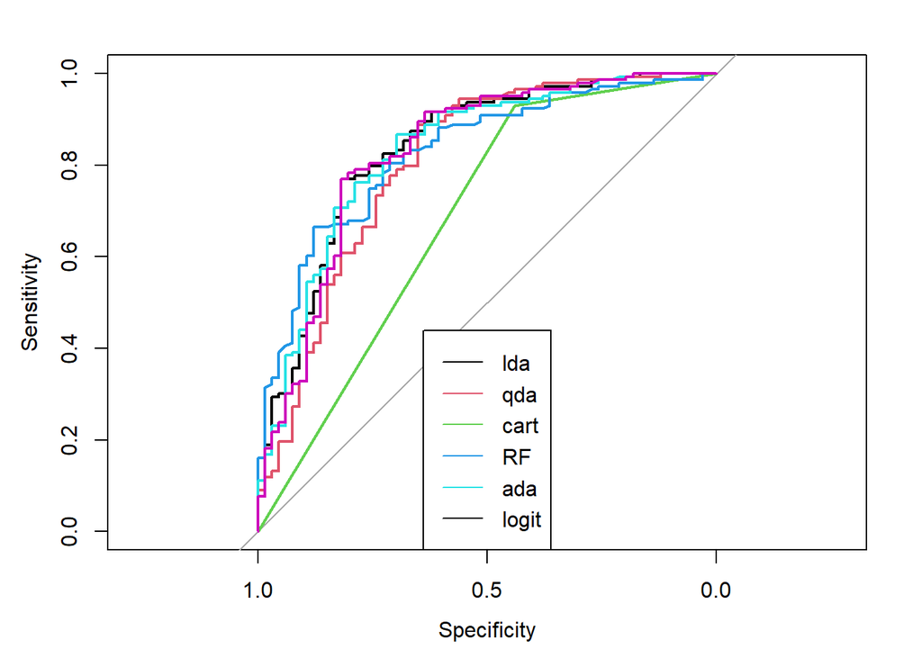

```r
plot(ROC_lda, xlim=c(1,0))
plot(ROC_qda, add=TRUE, col=2)
plot(ROC_cart, add=TRUE, col=3)
plot(ROC_RF, add=TRUE, col=4)
plot(ROC_adaboost, add=TRUE, col=5)
plot(ROC_logit, add=TRUE, col=6)
legend('bottom', col=1:5, paste(c('lda', 'qda', 'cart', 'RF', "ada","logit")),  lwd=1)
```

##ACP

```r
data_quanti=df[,c(3,13,14,15,31,32,33,34)]
head(data_quanti)
```

```
##   age traveltime studytime failures G1 G2 G3       Moy
## 1  18          2         2        0  5  6  6  5.666667
## 2  17          1         2        0  5  5  6  5.333333
## 3  15          1         2        3  7  8 10  8.333333
## 4  15          1         3        0 15 14 15 14.666667
## 5  16          1         2        0  6 10 10  8.666667
## 6  16          1         2        0 15 15 15 15.000000
```

On va par la suite transformer lorsque cela est possible certaines variables qualitatives en variables quantitatives afin de pouvoir réaliser une ACP dessus. Pour les variables studytime et traveltime, des intervalles nous sont données, on prend donc pour chaque niveau le millieu de l’intervalle. Pour les valeurs extrèmes, 1 et 4, on choisit arbitrairement une borne supèrieure ou inférieure (15H00 pour studytime et 3h00 pour traveltime pour ce qu’il s’agit des bornes supérieures et 0h00 pour les deux bornes inférieures)

```r
#on convertit studytime et travel time en variables quantitatives (on prend le millieux des segments)
for (i in 1:nrow(data_quanti)){
  if (data_quanti$studytime[i]==2){
    data_quanti$studytime[i]=210
  }
   if (data_quanti$studytime[i]==1){
    data_quanti$studytime[i]=120
   }
   if (data_quanti$studytime[i]==3){
    data_quanti$studytime[i]=450
   }
   if (data_quanti$studytime[i]==4){
    data_quanti$studytime[i]=750
   }
  if(data_quanti$traveltime[i]==1){
    data_quanti$traveltime[i]=7.5
  }
   if(data_quanti$traveltime[i]==2){
    data_quanti$traveltime[i]=22.5
   }
   if(data_quanti$traveltime[i]==3){
    data_quanti$traveltime[i]=45
   }
   if(data_quanti$traveltime[i]==4){
    data_quanti$traveltime[i]=120
  }


}
head(data_quanti)
```

```
##   age traveltime studytime failures G1 G2 G3       Moy
## 1  18       22.5       210        0  5  6  6  5.666667
## 2  17        7.5       210        0  5  5  6  5.333333
## 3  15        7.5       210        3  7  8 10  8.333333
## 4  15        7.5       450        0 15 14 15 14.666667
## 5  16        7.5       210        0  6 10 10  8.666667
## 6  16        7.5       210        0 15 15 15 15.000000
```

```r
res=PCA(data_quanti)
```

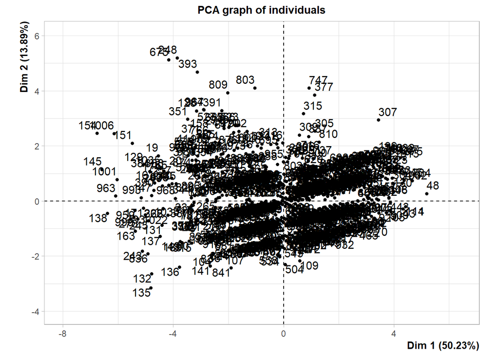

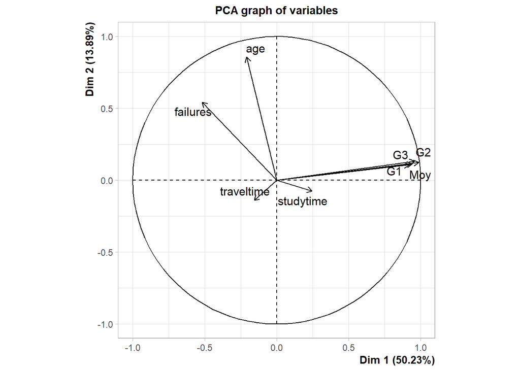

On voit que les variables study time et travel time sont mal projetées, on ne peut donc pas les interprétes. De manière logique on retrouve que les élèves ayant une bonne moyenne ont eu un bonne note à chaque semestres Vers la gauche se trouvent les paramètres ayant une influence négatives que la moyenne comme les echecs et plus curieusement l’âge (peut être sagit il des personnes ayant redoubler).

```r
res$eig
```

```
##          eigenvalue percentage of variance cumulative percentage of variance
## comp 1 4.018158e+00           5.022697e+01                          50.22697
## comp 2 1.111100e+00           1.388875e+01                          64.11572
## comp 3 9.810219e-01           1.226277e+01                          76.37850
## comp 4 9.605297e-01           1.200662e+01                          88.38512
## comp 5 6.518265e-01           8.147831e+00                          96.53295
## comp 6 1.970800e-01           2.463500e+00                          98.99645
## comp 7 8.028406e-02           1.003551e+00                         100.00000
## comp 8 1.593875e-30           1.992344e-29                         100.00000
```

On ne garde que deux dimensions ici, d’ou l’analyse ci dessus

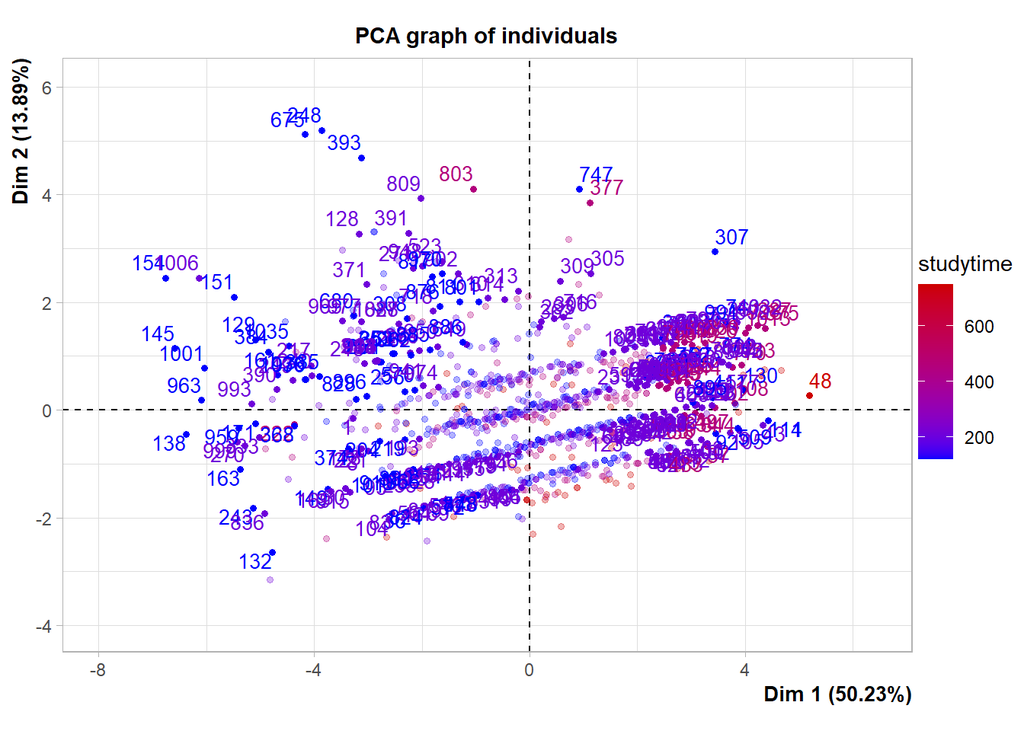

```r
plot(res, select="cos2 0.8", habillage=3, cex=0.9,choix="ind")#on visualise le temps de travail
```

On retrouve bien que les personnes ayant le plus travaillé se situé di coté des bonnes notes.

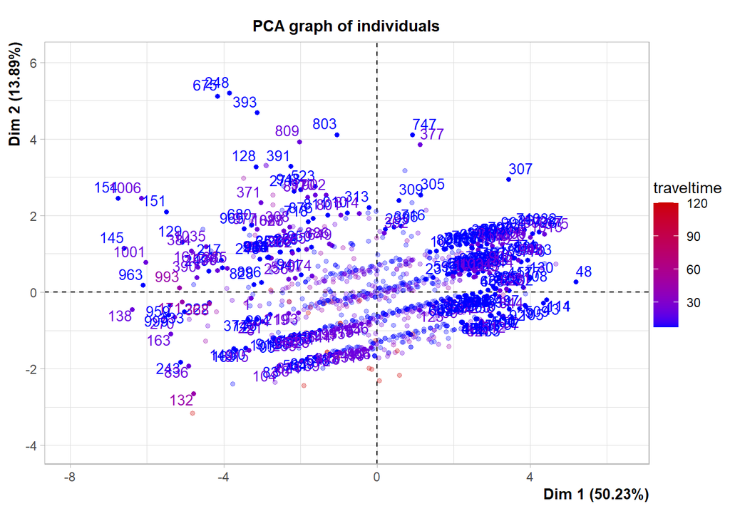

```r
plot(res, select="cos2 0.8", habillage=2, cex=0.9,choix="ind")#visualisation du temps de trajet
```

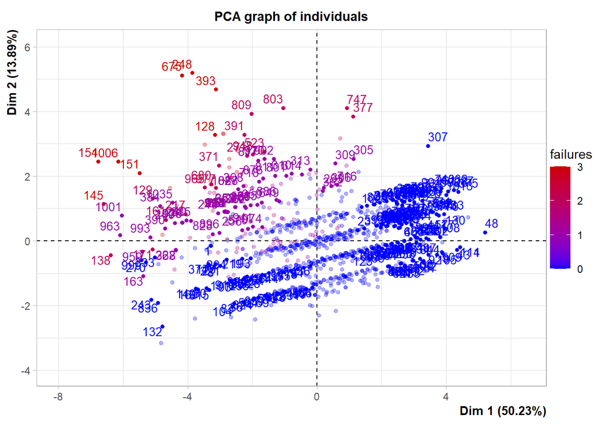

```r
plot(res, select="cos2 0.8", habillage=4, cex=0.9,choix="ind")#visualisation des échecs
```

```r
#création de la data frame correspondante
data_anova=df[,c(13,14,34)]
data_anova$traveltime=factor(data_anova$traveltime)
data_anova$studytime=factor(data_anova$studytime)
attach(data_anova)
```

```
## Les objets suivants sont masqués depuis data_quanti:
##
##     studytime, traveltime
```

```r
head(data_anova)
```

```
##   traveltime studytime       Moy
## 1          2         2  5.666667
## 2          1         2  5.333333
## 3          1         2  8.333333
## 4          1         3 14.666667
## 5          1         2  8.666667
## 6          1         2 15.000000
```

```r
table(data_anova$traveltime,data_anova$studytime)
```

```
##
##       1   2   3   4
##   1 165 314 108  36
##   2 110 143  46  21
##   3  34  37   4   2
##   4   8   9   4   3
```

Le plan est trop désiquilibré pour faire un anova ##Anova 2 sur les variables romantic et Walc

```r
#création de la data frame correspondante
head(df)
```

```
##   school sex age address famsize Pstatus Medu Fedu     Mjob     Fjob     reason
## 1     GP   F  18       U     GT3       A    4    4  at_home  teacher     course
## 2     GP   F  17       U     GT3       T    1    1  at_home    other     course
## 3     GP   F  15       U     LE3       T    1    1  at_home    other      other
## 4     GP   F  15       U     GT3       T    4    2   health services       home
## 5     GP   F  16       U     GT3       T    3    3    other    other       home
## 6     GP   M  16       U     LE3       T    4    3 services    other reputation
##   guardian traveltime studytime failures schoolsup famsup paid activities
## 1   mother          2         2        0       yes     no   no         no
## 2   father          1         2        0        no    yes   no         no
## 3   mother          1         2        3       yes     no  yes         no
## 4   mother          1         3        0        no    yes  yes        yes
## 5   father          1         2        0        no    yes  yes         no
## 6   mother          1         2        0        no    yes  yes        yes
##   nursery higher internet romantic famrel freetime goout Dalc Walc health
## 1     yes    yes       no       no      4        3     4    1    1      3
## 2      no    yes      yes       no      5        3     3    1    1      3
## 3     yes    yes      yes       no      4        3     2    2    3      3
## 4     yes    yes      yes      yes      3        2     2    1    1      5
## 5     yes    yes       no       no      4        3     2    1    2      5
## 6     yes    yes      yes       no      5        4     2    1    2      5
##   absences G1 G2 G3       Moy    RS
## 1        6  5  6  6  5.666667 FALSE
## 2        4  5  5  6  5.333333 FALSE
## 3       10  7  8 10  8.333333 FALSE
## 4        2 15 14 15 14.666667  TRUE
## 5        4  6 10 10  8.666667 FALSE
## 6       10 15 15 15 15.000000  TRUE
```

```r
data_anova=df[,c(28,23,34)]
data_anova$Walc=factor(data_anova$Walc)
head(data_anova)
```

```
##   Walc romantic       Moy
## 1    1       no  5.666667
## 2    1       no  5.333333
## 3    3       no  8.333333
## 4    1      yes 14.666667
## 5    2       no  8.666667
## 6    2       no 15.000000
```

```r
table(data_anova$Walc,data_anova$romantic)
```

```
##
##      no yes
##   1 253 145
##   2 151  84
##   3 127  73
##   4  98  40
##   5  44  29
```

Le modèle est complet et n’est pas trop désiquilibré.

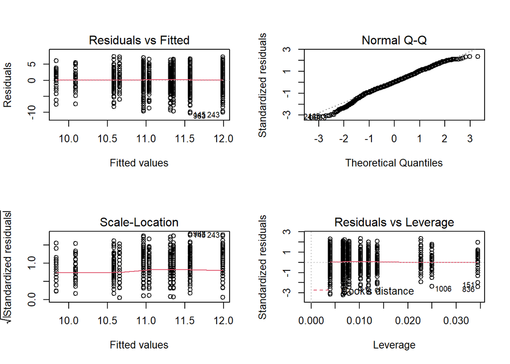

```r
res=lm(Moy~romantic*Walc,data_anova)
par(mfrow=c(2,2))
plot(res)
```

```r
shapiro.test(res$residuals)
```

```
##
##  Shapiro-Wilk normality test
##
## data:  res$residuals
## W = 0.98902, p-value = 4.858e-07
```

Les données ne sont pas du tout gaussiennes.

```r
head(df)
```

```
##   school sex age address famsize Pstatus Medu Fedu     Mjob     Fjob     reason
## 1     GP   F  18       U     GT3       A    4    4  at_home  teacher     course
## 2     GP   F  17       U     GT3       T    1    1  at_home    other     course
## 3     GP   F  15       U     LE3       T    1    1  at_home    other      other
## 4     GP   F  15       U     GT3       T    4    2   health services       home
## 5     GP   F  16       U     GT3       T    3    3    other    other       home
## 6     GP   M  16       U     LE3       T    4    3 services    other reputation
##   guardian traveltime studytime failures schoolsup famsup paid activities
## 1   mother          2         2        0       yes     no   no         no
## 2   father          1         2        0        no    yes   no         no
## 3   mother          1         2        3       yes     no  yes         no
## 4   mother          1         3        0        no    yes  yes        yes
## 5   father          1         2        0        no    yes  yes         no
## 6   mother          1         2        0        no    yes  yes        yes
##   nursery higher internet romantic famrel freetime goout Dalc Walc health
## 1     yes    yes       no       no      4        3     4    1    1      3
## 2      no    yes      yes       no      5        3     3    1    1      3
## 3     yes    yes      yes       no      4        3     2    2    3      3
## 4     yes    yes      yes      yes      3        2     2    1    1      5
## 5     yes    yes       no       no      4        3     2    1    2      5
## 6     yes    yes      yes       no      5        4     2    1    2      5
##   absences G1 G2 G3       Moy    RS
## 1        6  5  6  6  5.666667 FALSE
## 2        4  5  5  6  5.333333 FALSE
## 3       10  7  8 10  8.333333 FALSE
## 4        2 15 14 15 14.666667  TRUE
## 5        4  6 10 10  8.666667 FALSE
## 6       10 15 15 15 15.000000  TRUE
```

```r
data_anova=df[c(34,18,22)]
head(data_anova)
```

```
##         Moy paid internet
## 1  5.666667   no       no
## 2  5.333333   no      yes
## 3  8.333333  yes      yes
## 4 14.666667  yes      yes
## 5  8.666667  yes       no
## 6 15.000000  yes      yes
```

```r
table(data_anova$internet,data_anova$paid)
```

```
##
##        no yes
##   no  191  26
##   yes 633 194
```

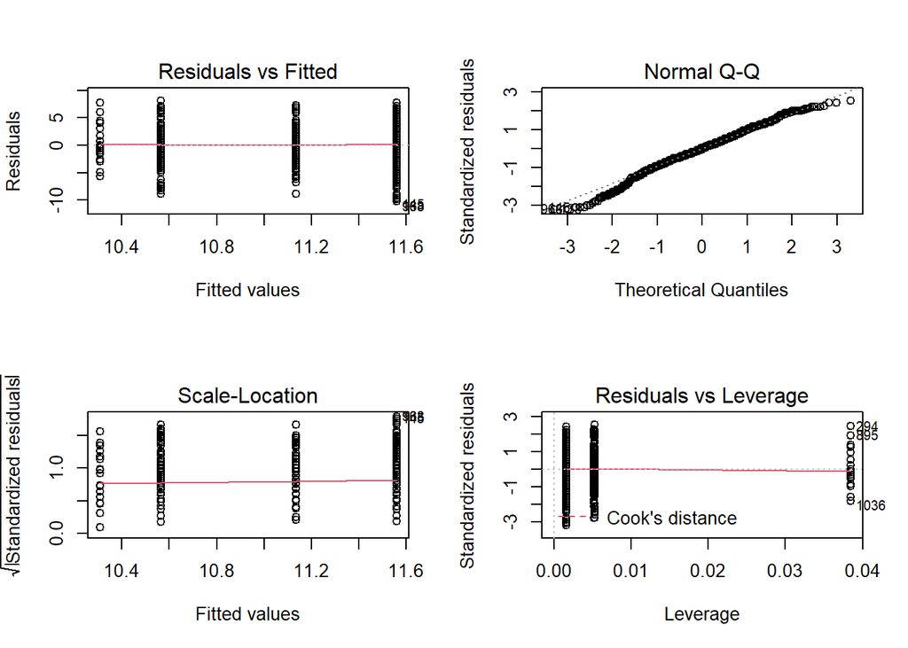

```r
res=lm(Moy~internet*paid,data_anova)
par(mfrow=c(2,2))
plot(res)
```

```r
shapiro.test(res$residuals)
```

```
##
##  Shapiro-Wilk normality test
##
## data:  res$residuals
## W = 0.99028, p-value = 2.162e-06
```

On obtiens encore que les données ne sont pas gaussiennes

##Modèle linéaire Gaussien: Régréssion mutliple

```r
library(car) #pour utiliser VIF
reg=lm(Moy~.,data_quanti)#regression multiple pour utiliser VIF
vif(reg)#test de colinéarité
```

```
##        age traveltime  studytime   failures         G1         G2         G3
##   1.087837   1.027492   1.048104   1.278165   3.943316   7.959427   6.069691
```

Aucune valeur n’est plsu grande que 10, la matrice est donc de plein rang. On va maintenant vérifier si les résidus sont iid, gaussiens centrée et réduits

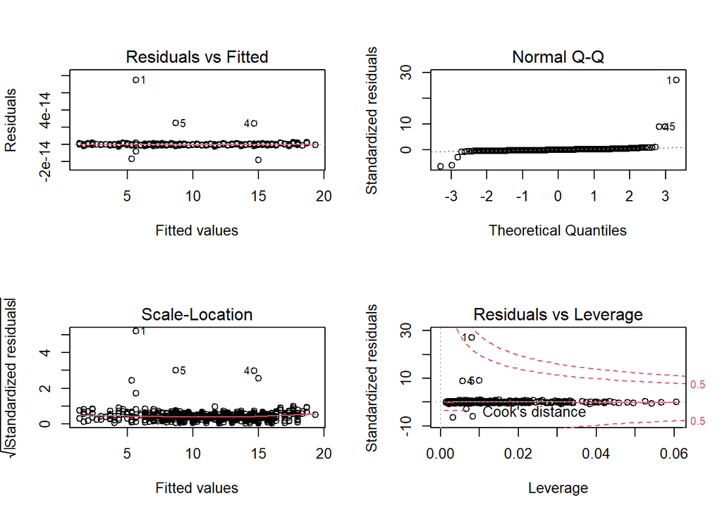

```r
par(mfrow=c(2,2))
plot(reg)
```

On voit qu’il n’y a pas de forme de trompette sur le graphe des résidus don l’hypoithèse d’homoscedasticité est vérifiée. Néanmoins il semble y avoir plusieurs points avec des résidus trop grands.

```r
abs(rstudent(reg))[abs(rstudent(reg))>2]
```

```
##         1         2         4         5         6         8
## 50.412602  6.120782  9.311399  9.394551  6.639145  2.980612
```

```r
shapiro.test(reg$residuals)
```

```
##
##  Shapiro-Wilk normality test
##
## data:  reg$residuals
## W = 0.17122, p-value < 2.2e-16
```